# Sauerkraut study - Model-based alpha diversity analysis

## Final model (Gaussian)

##### Estimated effects

```r
m_dca <- outputList_dca$model_gaussian

APCtools::create_modelSummary(list("Dominance core abundance" = m_dca), digits = 3)[[1]] %>% kable_styling()
```

| model | param | coef | se | CI_lower | CI_upper | pvalue |
| --- | --- | --- | --- | --- | --- | --- |
| Dominance core abundance | (Intercept) | 0.790 | 0.016 | 0.759 | 0.822 | - |
| Dominance core abundance | interventionFresh | -0.002 | 0.006 | -0.015 | 0.011 | 0.7625 |
| Dominance core abundance | interventionPasteurized | 0.002 | 0.007 | -0.011 | 0.014 | 0.8081 |
| Dominance core abundance | phasephase 2 | -0.002 | 0.005 | -0.012 | 0.009 | 0.7471 |
| Dominance core abundance | genderW | -0.012 | 0.021 | -0.054 | 0.030 | 0.5755 |
| Dominance core abundance | age_centered50 | -0.002 | 0.001 | -0.003 | 0.000 | 0.0152 |
| Dominance core abundance | bmi_centered25 | 0.000 | 0.004 | -0.007 | 0.008 | 0.9124 |

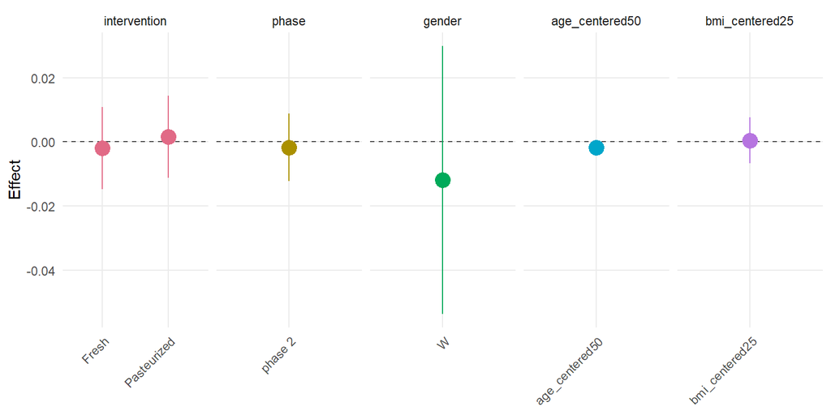

```r
APCtools::plot_linearEffects(m_dca)
```

```r
# save the interaction models for later use for visualization
m_dca_sexInt            <- outputList_dca$model_gaussian_sexInt
m_dca_sexInt_changedRef <- outputList_dca$model_gaussian_sexInt_changedRef
m_dca_ageInt            <- outputList_dca$model_gaussian_ageInt
m_dca_ageInt_changedRef <- outputList_dca$model_gaussian_ageInt_changedRef
m_dca_bmiInt            <- outputList_dca$model_gaussian_bmiInt
m_dca_bmiInt_changedRef <- outputList_dca$model_gaussian_bmiInt_changedRef
m_dca_fibInt            <- outputList_dca$model_gaussian_fibInt
m_dca_fibInt_changedRef <- outputList_dca$model_gaussian_fibInt_changedRef
m_dca_divInt            <- outputList_dca$model_gaussian_divInt
m_dca_divInt_changedRef <- outputList_dca$model_gaussian_divInt_changedRef
```

# Rarity log modulo skewness

Note: The rarity distribution shows some extreme outliers. However, the pasteurized intervention effect remains significant (regarding the uncorrected p-value) even when trimming all outliers to 1.98.

## Description

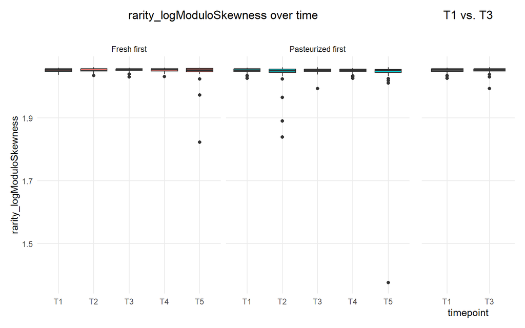

```r
plot_variable(dat, "rarity_logModuloSkewness", cut_extremeValues = FALSE)
```

## Model comparison

Share of deviance explained (including p-values for testing the respective interaction model against the model without interaction):

```r
outputList_rar <- compare_models("rarity_logModuloSkewness")

outputList_rar$tab_explainedDeviances %>% kable() %>% kable_styling()
```

| Model | Gaussian | Gaussian (log trafo) | Gamma |
| --- | --- | --- | --- |
| Raw intervention effect | 18.1% | 17.2% | 15.3% |
| Intervention effect by gender | 18.2% (p = 0.8529) | 17.3% (p = 0.8601) | 15.3% (p = 0.8437) |
| Intervention effect by age group | 18.1% (p = 0.9999) | 17.2% (p = 0.9999) | 15.2% (p = 0.9999) |
| Intervention effect by BMI group | 18.3% (p = 0.8507) | 17.4% (p = 0.8261) | 15.4% (p = 0.8448) |
| Intervention effect by fiber group | 18.3% (p = 0.6464) | 17.4% (p = 0.6388) | 15.4% (p = 0.6497) |
| Intervention effect by baseline diversity | 19% (p = 0.1163) | 18.2% (p = 0.1263) | 16.2% (p = 0.1187) |

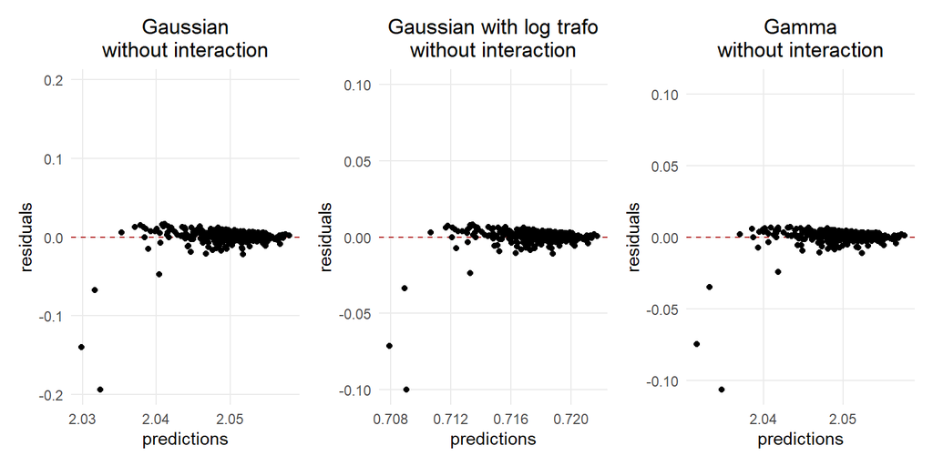

```r
outputList_rar$gg_residuals
```

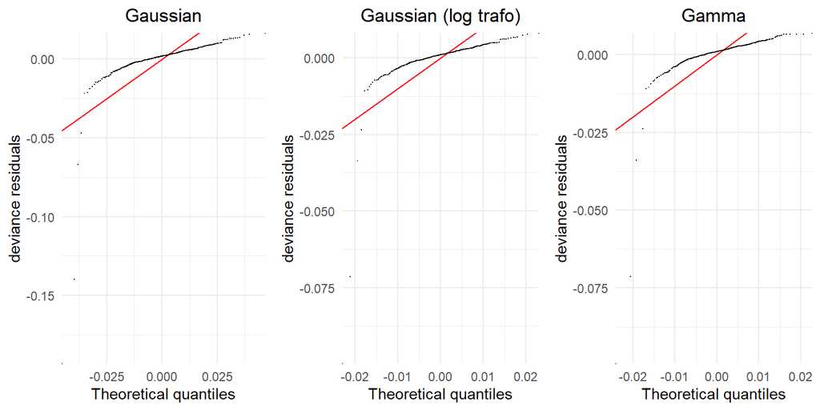

```r
mgcViz::gridPrint(outputList_rar$qq_gaussian, outputList_rar$qq_gaussianLog, outputList_rar$qq_gamma, nrow = 1)
```

## Final model (Gaussian)

##### Estimated effects

```r
m_rar <- outputList_rar$model_gaussian

APCtools::create_modelSummary(list("Rarity log modulo skewness" = m_rar), digits = 3)[[1]] %>% kable_styling()
```

| model | param | coef | se | CI_lower | CI_upper | pvalue |
| --- | --- | --- | --- | --- | --- | --- |
| Rarity log modulo skewness | (Intercept) | 2.048 | 0.002 | 2.044 | 2.052 | - |
| Rarity log modulo skewness | interventionFresh | 0.000 | 0.002 | -0.004 | 0.004 | 0.8746 |
| Rarity log modulo skewness | interventionPasteurized | -0.005 | 0.002 | -0.010 | -0.001 | 0.0099 |
| Rarity log modulo skewness | phasephase 2 | 0.003 | 0.002 | 0.000 | 0.007 | 0.059 |
| Rarity log modulo skewness | genderW | 0.004 | 0.002 | 0.000 | 0.008 | 0.0851 |
| Rarity log modulo skewness | age_centered50 | 0.000 | 0.000 | 0.000 | 0.000 | 0.1826 |
| Rarity log modulo skewness | bmi_centered25 | 0.000 | 0.000 | -0.001 | 0.001 | 0.7165 |

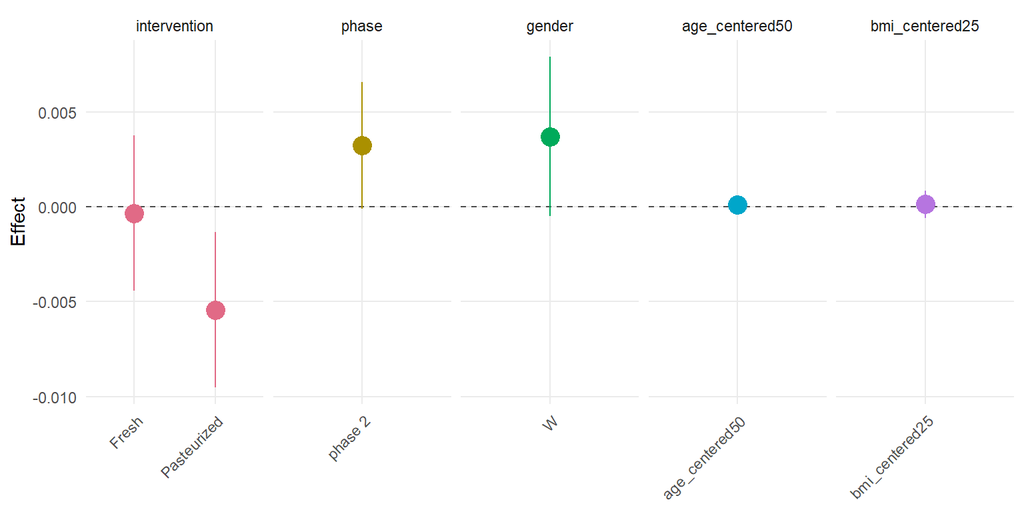

```r
APCtools::plot_linearEffects(m_rar)
```

```r
# save the interaction models for later use for visualization
m_rar_sexInt            <- outputList_rar$model_gaussian_sexInt
m_rar_sexInt_changedRef <- outputList_rar$model_gaussian_sexInt_changedRef
m_rar_ageInt            <- outputList_rar$model_gaussian_ageInt
m_rar_ageInt_changedRef <- outputList_rar$model_gaussian_ageInt_changedRef
m_rar_bmiInt            <- outputList_rar$model_gaussian_bmiInt
m_rar_bmiInt_changedRef <- outputList_rar$model_gaussian_bmiInt_changedRef
m_rar_fibInt            <- outputList_rar$model_gaussian_fibInt
m_rar_fibInt_changedRef <- outputList_rar$model_gaussian_fibInt_changedRef
m_rar_divInt            <- outputList_rar$model_gaussian_divInt
m_rar_divInt_changedRef <- outputList_rar$model_gaussian_divInt_changedRef
```

# Not used: Divergence to median

## Description

```r
# plot_variable(dat, "divergence_toMedian", cut_extremeValues = FALSE)
```

## Model comparison

Share of deviance explained (including p-values for testing the respective interaction model against the model without interaction):

```r
# outputList_dtm <- compare_models("divergence_toMedian")
#
# outputList_dtm$tab_explainedDeviances %>% kable() %>% kable_styling()
# outputList_dtm$gg_residuals
# mgcViz::gridPrint(outputList_dtm$qq_gaussian, outputList_dtm$qq_gaussianLog, outputList_dtm$qq_gamma, nrow = 1)
```

## Final model (Gaussian)

##### Estimated effects

```r
# m_dtm <- outputList_dtm$model_gaussian
#
# APCtools::create_modelSummary(list("Divergence to median" = m_dtm), digits = 3)[[1]] %>% kable_styling()
# APCtools::plot_linearEffects(m_dtm)
#
# # save the interaction models for later use for visualization
# m_dtm_sexInt            <- outputList_dtm$model_gaussian_sexInt
# m_dtm_sexInt_changedRef <- outputList_dtm$model_gaussian_sexInt_changedRef
# m_dtm_ageInt            <- outputList_dtm$model_gaussian_ageInt
# m_dtm_ageInt_changedRef <- outputList_dtm$model_gaussian_ageInt_changedRef
# m_dtm_bmiInt            <- outputList_dtm$model_gaussian_bmiInt
# m_dtm_bmiInt_changedRef <- outputList_dtm$model_gaussian_bmiInt_changedRef
```

# Overview table of all models

```r
# create a joint vector of all variables
model_names <- markers[markers != "divergence_toMedian"]
# create a model list
model_list <- list("Diversity (Shannon)"          = m_dvs,
                   "Diversity (inv. Simpson)"     = m_dvi,
                   "Richness (observed)"          = m_rno,
                   "Richness (Hill)"              = m_rnh,
                   "Evenness (Pielou)"            = m_enp,
                   "Evenness (Simpson)"           = m_ens,
                   "Dominance (DBP)"              = m_dbp,
                   "Dominance (core abundance)"   = m_dca,
                   "Rarity (log modulo skewness)" = m_rar)
                   # "Divergence (to median)"       = m_dtm)
model_sexInt_list <- list("Diversity (Shannon)"          = list(m_dvs_sexInt, m_dvs_sexInt_changedRef),
                          "Diversity (inv. Simpson)"     = list(m_dvi_sexInt, m_dvi_sexInt_changedRef),
                          "Richness (observed)"          = list(m_rno_sexInt, m_rno_sexInt_changedRef),
                          "Richness (Hill)"              = list(m_rnh_sexInt, m_rnh_sexInt_changedRef),
                          "Evenness (Pielou)"            = list(m_enp_sexInt, m_enp_sexInt_changedRef),
                          "Evenness (Simpson)"           = list(m_ens_sexInt, m_ens_sexInt_changedRef),
                          "Dominance (DBP)"              = list(m_dbp_sexInt, m_dbp_sexInt_changedRef),
                          "Dominance (core abundance)"   = list(m_dca_sexInt, m_dca_sexInt_changedRef),
                          "Rarity (log modulo skewness)" = list(m_rar_sexInt, m_rar_sexInt_changedRef))
                          # "Divergence (to median)"       = list(m_dtm_sexInt, m_dtm_sexInt_changedRef))
model_ageInt_list <- list("Diversity (Shannon)"          = list(m_dvs_ageInt, m_dvs_ageInt_changedRef),
                          "Diversity (inv. Simpson)"     = list(m_dvi_ageInt, m_dvi_ageInt_changedRef),
                          "Richness (observed)"          = list(m_rno_ageInt, m_rno_ageInt_changedRef),
                          "Richness (Hill)"              = list(m_rnh_ageInt, m_rnh_ageInt_changedRef),
                          "Evenness (Pielou)"            = list(m_enp_ageInt, m_enp_ageInt_changedRef),
                          "Evenness (Simpson)"           = list(m_ens_ageInt, m_ens_ageInt_changedRef),
                          "Dominance (DBP)"              = list(m_dbp_ageInt, m_dbp_ageInt_changedRef),
                          "Dominance (core abundance)"   = list(m_dca_ageInt, m_dca_ageInt_changedRef),
                          "Rarity (log modulo skewness)" = list(m_rar_ageInt, m_rar_ageInt_changedRef))
                          # "Divergence (to median)"       = list(m_dtm_ageInt, m_dtm_ageInt_changedRef))
model_bmiInt_list <- list("Diversity (Shannon)"          = list(m_dvs_bmiInt, m_dvs_bmiInt_changedRef),
                          "Diversity (inv. Simpson)"     = list(m_dvi_bmiInt, m_dvi_bmiInt_changedRef),
                          "Richness (observed)"          = list(m_rno_bmiInt, m_rno_bmiInt_changedRef),
                          "Richness (Hill)"              = list(m_rnh_bmiInt, m_rnh_bmiInt_changedRef),
                          "Evenness (Pielou)"            = list(m_enp_bmiInt, m_enp_bmiInt_changedRef),
                          "Evenness (Simpson)"           = list(m_ens_bmiInt, m_ens_bmiInt_changedRef),
                          "Dominance (DBP)"              = list(m_dbp_bmiInt, m_dbp_bmiInt_changedRef),
                          "Dominance (core abundance)"   = list(m_dca_bmiInt, m_dca_bmiInt_changedRef),
                          "Rarity (log modulo skewness)" = list(m_rar_bmiInt, m_rar_bmiInt_changedRef))
                          # "Divergence (to median)"       = list(m_dtm_bmiInt, m_dtm_bmiInt_changedRef))
model_fibInt_list <- list("Diversity (Shannon)"          = list(m_dvs_fibInt, m_dvs_fibInt_changedRef),
                          "Diversity (inv. Simpson)"     = list(m_dvi_fibInt, m_dvi_fibInt_changedRef),
                          "Richness (observed)"          = list(m_rno_fibInt, m_rno_fibInt_changedRef),
                          "Richness (Hill)"              = list(m_rnh_fibInt, m_rnh_fibInt_changedRef),
                          "Evenness (Pielou)"            = list(m_enp_fibInt, m_enp_fibInt_changedRef),
                          "Evenness (Simpson)"           = list(m_ens_fibInt, m_ens_fibInt_changedRef),
                          "Dominance (DBP)"              = list(m_dbp_fibInt, m_dbp_fibInt_changedRef),
                          "Dominance (core abundance)"   = list(m_dca_fibInt, m_dca_fibInt_changedRef),
                          "Rarity (log modulo skewness)" = list(m_rar_fibInt, m_rar_fibInt_changedRef))
                          # "Divergence (to median)"       = list(m_dtm_fibInt, m_dtm_fibInt_changedRef))
model_divInt_list <- list("Diversity (Shannon)"          = list(m_dvs_divInt, m_dvs_divInt_changedRef),
                          "Diversity (inv. Simpson)"     = list(m_dvi_divInt, m_dvi_divInt_changedRef),
                          "Richness (observed)"          = list(m_rno_divInt, m_rno_divInt_changedRef),
                          "Richness (Hill)"              = list(m_rnh_divInt, m_rnh_divInt_changedRef),
                          "Evenness (Pielou)"            = list(m_enp_divInt, m_enp_divInt_changedRef),
                          "Evenness (Simpson)"           = list(m_ens_divInt, m_ens_divInt_changedRef),
                          "Dominance (DBP)"              = list(m_dbp_divInt, m_dbp_divInt_changedRef),
                          "Dominance (core abundance)"   = list(m_dca_divInt, m_dca_divInt_changedRef),
                          "Rarity (log modulo skewness)" = list(m_rar_divInt, m_rar_divInt_changedRef))
                          # "Divergence (to median)"       = list(m_dtm_divInt, m_dtm_divInt_changedRef))
# create a lookup list for the final model type
modelType_list <- list("Diversity (Shannon)"          = "Gaussian",
                       "Diversity (inv. Simpson)"     = "Gaussian",
                       "Richness (observed)"          = "Gaussian",
                       "Richness (Hill)"              = "Gaussian",
                       "Evenness (Pielou)"            = "Gaussian",
                       "Evenness (Simpson)"           = "log Gaussian",
                       "Dominance (DBP)"              = "Gamma",
                       "Dominance (core abundance)"   = "Gaussian",
                       "Rarity (log modulo skewness)" = "Gaussian")
                       # "Divergence (to median)"       = "Gaussian")

# overview table
data.frame(Model              = names(model_list),
           Model_type         = unlist(modelType_list, use.names = FALSE),
           Deviance_explained = sapply(model_list, function(x) { paste0(round(100 * summary(x)$dev.expl, 1), "%") }, USE.NAMES = FALSE) %>% unname()) %>%
  kable() %>%
  kable_styling()
```

[output not shown]

# Joint plot of all effects

```r
# create a results table with all effects
modelResults_list <- lapply(names(model_names), function(x) {

  variable   <- model_names[x] %>% unname()
  model      <- model_list[[x]]
  model_type <- modelType_list[[x]]

  log_wasApplied <- (model_type %in% c("Gamma", "log Gaussian"))

  results_dat <- summary(model)$p.table %>%
    as.data.frame() %>%
    mutate(parameter   = row.names(.),
           param_group = case_when(parameter %in% c("interventionFresh", "interventionPasteurized") ~ "intervention",
                                   grepl("carry_over", parameter)                                   ~ "carry-over",
                                   grepl("phase", parameter)                                        ~ "phase",
                                   grepl("gender", parameter)                                       ~ "gender",
                                   grepl("bmi", parameter)                                          ~ "BMI",
                                   grepl("age", parameter)                                          ~ "age",
                                   TRUE                                                             ~ parameter)) %>%
    dplyr::rename(estimate   = "Estimate",
                  se         = "Std. Error",
                  pvalue     = "Pr(>|t|)") %>%
    mutate(model      = x,
           model_type = model_type,
           CI_lower   = estimate - qnorm(0.975) * se,
           CI_upper   = estimate + qnorm(0.975) * se)

  if (!log_wasApplied) { # standardize the effects by the standard deviation of the response variable
    results_dat <- results_dat %>%
      mutate(y_sd = sd(dat_model[[variable]], na.rm = TRUE),
             estimate_standardized = estimate / y_sd,
             se_standardized       = se / y_sd,
             CI_lower_standardized = estimate_standardized - qnorm(0.975) * se_standardized,
             CI_upper_standardized = estimate_standardized + qnorm(0.975) * se_standardized)

  } else { # exponentiate the effects
    results_dat <- results_dat %>%
      mutate(exp_estimate = exp(estimate),
             exp_CIlower  = exp(CI_lower),
             exp_CIupper  = exp(CI_upper),
             y_sd = NA)
  }

  results_dat <- results_dat %>%
    select(model, model_type, param_group, parameter, y_sd, estimate, CI_lower, CI_upper, pvalue, contains("standardized"), contains("exp"))
  row.names(results_dat) <- NULL

  return(results_dat)
})
results_dat <- modelResults_list %>% bind_rows() %>%
  mutate(model       = factor(model, levels = names(model_names)),
         model_group = sapply(as.character(model), function(x) { strsplit(x, split = " \\(")[[1]][1] }),
         model_group = factor(model_group, levels = unique(model_group)))
```

## Intervention effects

##### Heatmap

```r
# limit the data to the intervention effects and apply the p-value correction (Benjamini-Hochberg)
dat_base <- results_dat %>%
  filter(grepl("intervention", parameter)) %>%
  mutate(qvalue = p.adjust(pvalue, method = "BH"))

# prepare the base dataset for the plot
dat_plot <- data.frame(param         = c(dat_base$model[dat_base$parameter == "interventionFresh"],
                                         dat_base$model[dat_base$parameter == "interventionPasteurized"]),
                       model         = c(dat_base$model_type[dat_base$parameter == "interventionFresh"],
                                         dat_base$model_type[dat_base$parameter == "interventionPasteurized"]),
                       intervention  = rep(c("Fresh intervention", "Pasteurized intervention"), each = nrow(dat_base)/2),
                       effect        = c(dat_base$estimate[dat_base$parameter == "interventionFresh"],
                                         dat_base$estimate[dat_base$parameter == "interventionPasteurized"]),
                       qvalue        = c(dat_base$qvalue[dat_base$parameter == "interventionFresh"],
                                         dat_base$qvalue[dat_base$parameter == "interventionPasteurized"]),
                       pastEffect_forSorting = rep(dat_base$qvalue[dat_base$parameter == "interventionPasteurized"],
                                                   times = 2)) %>%
  arrange(desc(pastEffect_forSorting)) %>%
  mutate(baseline_medianValue = sapply(as.character(param), function(x) { median(dat[[markers[[x]]]][dat$inter_treat %in% c("Baseline.Fresh","Baseline.Pasteurized")]) }),
         qvalue_signif = case_when((qvalue < 0.1) & (intervention == "Fresh intervention") ~ "significant (fresh intervention)",
                                   qvalue < 0.1 ~ "significant (pasteurized intervention)",
                                   TRUE          ~ "not significant"),
         effect_label  = case_when(model == "Gaussian" ~ paste0(ifelse(effect > 0, "+", ""),
                                                                round(effect, 2)),
                                   TRUE                ~ paste0(ifelse(effect > 0, "+", ""),
                                                                paste0(round(100 * (exp(effect) - 1)), "%"))))

# artificially add the baseline rel. abd. as an 'intervention' and 'effect_label' to be able to nicely plot it
dat_plot_list <- lapply(as.character(unique(dat_plot$param)), function(pm) {
  dat_param <- dat_plot %>% filter(param == pm)
  dat_param %>%
    dplyr::bind_rows(data.frame(param         = pm,
                                intervention  = "Baseline median value",
                                qvalue_signif = "",
                                effect_label  = case_when(dat_param$baseline_medianValue < .0001 ~ "<0.0001",
                                                          dat_param$baseline_medianValue < .001  ~ as.character(round(dat_param$baseline_medianValue, 4)),
                                                          dat_param$baseline_medianValue < .01   ~ as.character(round(dat_param$baseline_medianValue, 3)),
                                                          dat_param$baseline_medianValue < 5     ~ as.character(round(dat_param$baseline_medianValue, 2)),
                                                          TRUE ~ as.character(round(dat_param$baseline_medianValue, 1)))))
})
dat_plot <- dat_plot_list %>% dplyr::bind_rows() %>%
  mutate(param        = factor(param, levels = rev(sort(unique(param)))),
         intervention = factor(intervention, levels = c("Baseline median value", "Fresh intervention", "Pasteurized intervention")))
```

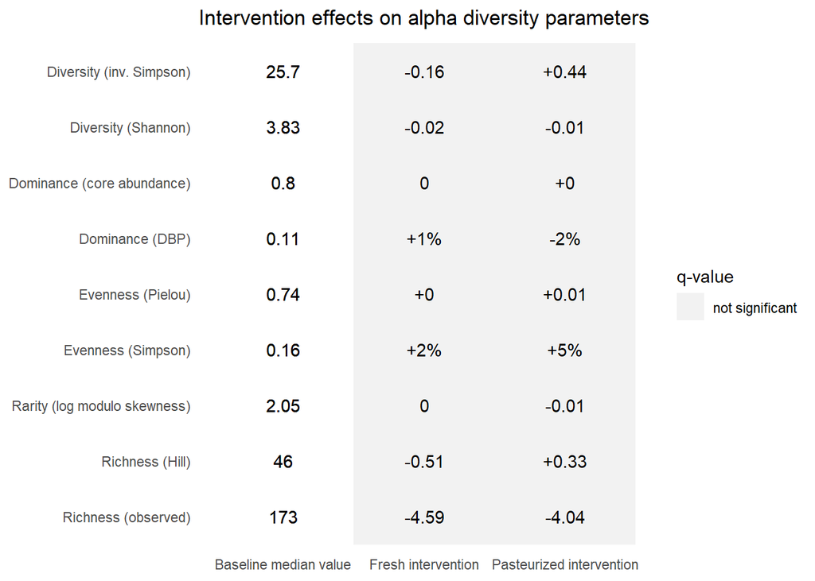

```r
# plot
dat_plot %>%
  ggplot(aes(x = intervention, y = param)) +
  geom_tile(aes(fill = qvalue_signif)) +
  geom_text(aes(label = effect_label)) +
  scale_fill_manual("q-value", values = c("not significant" = "gray95",
                                          "significant (fresh intervention)" = "#1F78B4",
                                          "significant (pasteurized intervention)" = "#FF7F00"),
                    na.value = "white") +
  ggtitle("Intervention effects on alpha diversity parameters") +
  theme(axis.title = element_blank(),
        panel.grid = element_blank(),
        strip.background = element_rect(fill = "gray97", color = "gray97"))
```

```r
# ggsave("alphaDiversity_modelResults_heatmap.png", width = 10, height = 6)
```

##### Classical effect plot

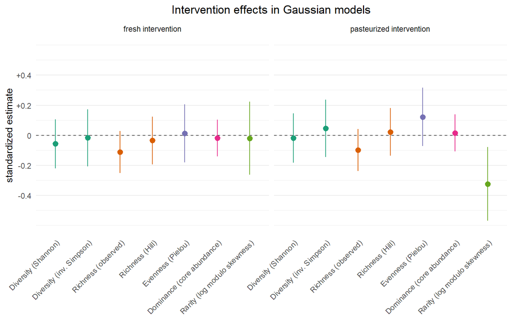

```r
# 1) effects of Gaussian models
ylim_gaussian <- c(-1,1) * max(abs(c(results_dat$CI_lower_standardized[results_dat$parameter != "(Intercept)"],
                                     results_dat$CI_upper_standardized[results_dat$parameter != "(Intercept)"])), na.rm = TRUE)
ylim_gaussianInt <- c(-.6, .6)
gg_gaussian <- results_dat %>%
  filter(model_type  == "Gaussian",
         param_group == "intervention") %>%
  mutate(parameter = factor(parameter, levels = c("interventionFresh", "interventionPasteurized"),
                            labels = c("fresh intervention", "pasteurized intervention")),
         model     = factor(model, levels = levels(model),
                            labels = levels(model) %>% gsub(pattern = " \\(Blood)", replacement = ""))) %>%
  ggplot(aes(x = model, y = estimate_standardized, color = model_group)) +
  geom_hline(yintercept = 0, linetype = 2, col = "gray30") +
  geom_pointrange(aes(ymin = CI_lower_standardized, ymax = CI_upper_standardized)) +
  geom_point() +
  scale_y_continuous("standardized estimate", limits = ylim_gaussianInt,
                     breaks = c(-.4,-.2,0,.2,.4),
                     labels = c("-0.4", "-0.2", "0", "+0.2", "+0.4")) +
  scale_color_brewer(palette = "Dark2") +
  facet_wrap(~ parameter) +
  ggtitle("Intervention effects in Gaussian models") +
  theme(axis.text.x        = element_text(hjust = 1, angle = 45),
        axis.title.x       = element_blank(),
        panel.grid.minor.y = element_line(color = "gray96"),
        panel.grid.major.x = element_blank(),
        legend.position    = "none")
gg_gaussian
```

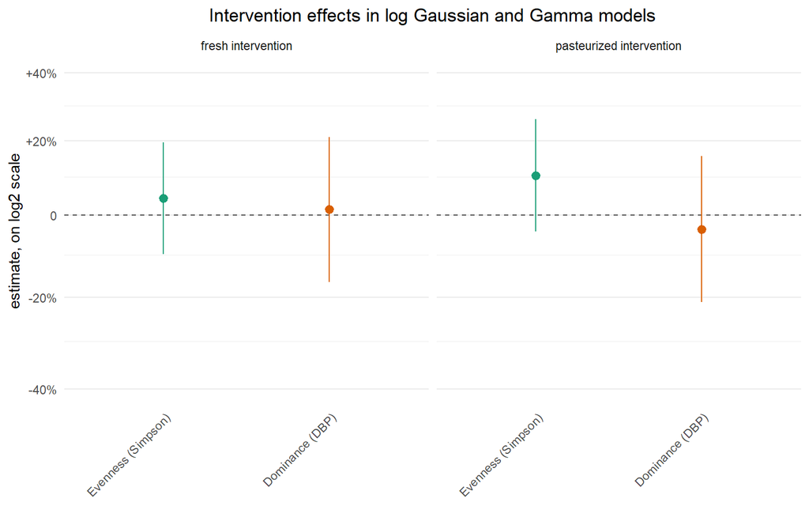

```r
# 2) effects of log Gaussian and Gamma models
ylim_log <- c(min(results_dat$exp_CIlower[results_dat$parameter != "(Intercept)"], na.rm = TRUE),
              max(results_dat$exp_CIupper[results_dat$parameter != "(Intercept)"], na.rm = TRUE))
ylim_logInt <- c(.8,1.2)
gg_exp <- results_dat %>%
  filter(model_type  != "Gaussian",
         param_group == "intervention") %>%
  mutate(parameter = factor(parameter, levels = c("interventionFresh", "interventionPasteurized"),
                            labels = c("fresh intervention", "pasteurized intervention")),
         model     = factor(model, levels = levels(model),
                            labels = levels(model) %>% gsub(pattern = " \\(Blood)", replacement = ""))) %>%
  ggplot(aes(x = model, y = exp_estimate, color = model_group)) +
  geom_hline(yintercept = 1, linetype = 2, col = "gray30") +
  geom_pointrange(aes(ymin = exp_CIlower, ymax = exp_CIupper)) +
  geom_point() +
  scale_y_continuous("estimate, on log2 scale", trans = "log2", limits = ylim_logInt,
                     breaks = c(.8, .9, 1, 1.1, 1.2),
                     labels = c("-40%", "-20%", "0", "+20%", "+40%"),
                     minor_breaks = c(.85, .95, 1.05, 1.15)) +
  scale_color_brewer(palette = "Dark2") +
  facet_wrap(~ parameter) +
  ggtitle("Intervention effects in log Gaussian and Gamma models") +
  theme(axis.text.x        = element_text(hjust = 1, angle = 45),
        axis.title.x       = element_blank(),
        panel.grid.minor.y = element_line(color = "gray96"),
        panel.grid.major.x = element_blank(),
        legend.position    = "none")
gg_exp
```

## Interactions: Intervention by baseline diversity

```r
# create a results table with all effects
modelResults_divInt_list <- lapply(names(model_names), function(x) {

  variable         <- model_names[x] %>% unname()
  model            <- model_divInt_list[[x]][[1]]
  model_changedRef <- model_divInt_list[[x]][[2]]
  model_type       <- modelType_list[[x]]

  log_wasApplied <- (model_type %in% c("Gamma", "log Gaussian"))

  results_dat1 <- summary(model)$p.table %>% as.data.frame() %>%
    mutate(parameter   = row.names(.)) %>%
    filter(grepl("intervention", parameter),
           !grepl(":", parameter)) %>%
    mutate(div_group = levels(dat_model$baselineDiv_cat)[1])
  results_dat2 <- summary(model_changedRef)$p.table %>% as.data.frame() %>%
    mutate(parameter   = row.names(.)) %>%
    filter(grepl("intervention", parameter),
           !grepl(":", parameter)) %>%
    mutate(div_group = levels(dat_model$baselineDiv_cat)[2])
  results_dat <- results_dat1 %>% dplyr::bind_rows(results_dat2) %>%
    dplyr::rename(estimate   = "Estimate",
                  se         = "Std. Error",
                  pvalue     = "Pr(>|t|)") %>%
    mutate(model      = x,
           model_type = model_type,
           CI_lower   = estimate - qnorm(0.975) * se,
           CI_upper   = estimate + qnorm(0.975) * se)

  if (!log_wasApplied) { # standardize the effects by the standard deviation of the respnse variable
    results_dat <- results_dat %>%
      mutate(y_sd = sd(dat_model[[variable]], na.rm = TRUE),
             estimate_standardized = estimate / y_sd,
             se_standardized       = se / y_sd,
             CI_lower_standardized = estimate_standardized - qnorm(0.975) * se_standardized,
             CI_upper_standardized = estimate_standardized + qnorm(0.975) * se_standardized)

  } else { # exponentiate the effects
    results_dat <- results_dat %>%
      mutate(exp_estimate = exp(estimate),
             exp_CIlower  = exp(CI_lower),
             exp_CIupper  = exp(CI_upper))
  }

  results_dat <- results_dat %>%
    select(model, model_type, div_group, parameter, estimate, CI_lower, CI_upper, contains("standardized"), contains("exp"), pvalue)
  row.names(results_dat) <- NULL

  return(results_dat)
})
results_dat_divInt <- modelResults_divInt_list %>% bind_rows() %>%
  mutate(model       = factor(model, levels = names(model_names)),
         model_group  = sapply(as.character(model), function(x) { strsplit(x, split = " \\(")[[1]][1] }),
         model_group  = factor(model_group, levels = unique(model_group)),
         xCoord_shift = case_when(div_group == min(div_group) ~ -0.15,
                                  TRUE                        ~ 0.15))
```

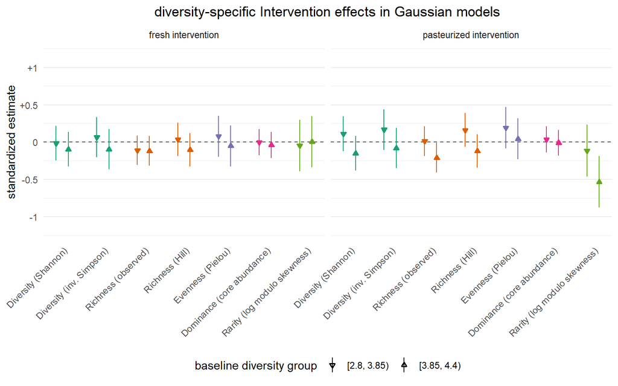

```r
# 1) effects of Gaussian models
ylim_gaussianInt <- c(-1.2, 1.2)
plot_dat_divInt <- results_dat_divInt %>%
  filter(model_type  == "Gaussian") %>%
  mutate(parameter = factor(parameter, levels = c("interventionFresh", "interventionPasteurized"),
                            labels = c("fresh intervention", "pasteurized intervention")),
         model     = droplevels(model),
         model     = factor(model, levels = levels(model),
                            labels = levels(model) %>% gsub(pattern = " \\(Blood)", replacement = "")),
         model_xCoord = as.numeric(model) + xCoord_shift)

gg_gaussian_divInt <- plot_dat_divInt %>%
  ggplot(aes(x = model_xCoord, y = estimate_standardized, color = model_group, fill = model_group)) +
  geom_hline(yintercept = 0, linetype = 2, col = "gray30") +
  geom_pointrange(aes(ymin = CI_lower_standardized, ymax = CI_upper_standardized, shape = div_group), size = 0.25) +
  scale_x_continuous(breaks = 1:length(levels(plot_dat_divInt$model)), labels = levels(plot_dat_divInt$model)) +
  scale_y_continuous("standardized estimate", limits = ylim_gaussianInt,
                     breaks = c(-1,-.5,0,.5,1),
                     labels = c("-1", "-0.5", "0", "+0.5", "+1")) +
  scale_color_brewer(palette = "Dark2", guide = "none") +
  scale_fill_brewer(palette = "Dark2", guide = "none") +
  scale_shape_manual("baseline diversity group", values = c(25,24)) +
  facet_wrap(~ parameter) +
  ggtitle("diversity-specific Intervention effects in Gaussian models") +
  theme(axis.text.x        = element_text(hjust = 1, angle = 45),
        axis.title.x       = element_blank(),
        panel.grid.minor.y = element_line(color = "gray96"),
        panel.grid.major.x = element_blank(),
        legend.position    = "bottom")
gg_gaussian_divInt
```

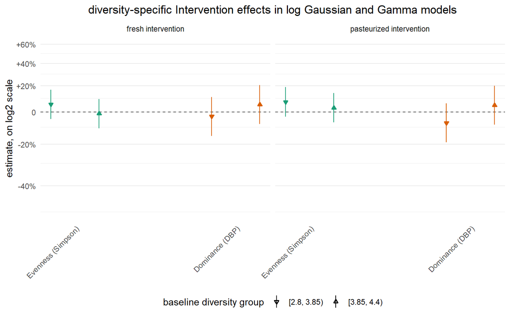

```r
# 2) effects of log Gaussian and Gamma models
ylim_logInt <- c(.5,1.6)
plot_dat_divInt_exp <- results_dat_divInt %>%
  filter(model_type  != "Gaussian") %>%
  mutate(parameter = factor(parameter, levels = c("interventionFresh", "interventionPasteurized"),
                            labels = c("fresh intervention", "pasteurized intervention")),
         model     = droplevels(model),
         model     = factor(model, levels = levels(model),
                            labels = levels(model) %>% gsub(pattern = " \\(Blood)", replacement = "")),
         model_xCoord = as.numeric(model) + xCoord_shift)

gg_exp_divInt <- plot_dat_divInt_exp %>%
  ggplot(aes(x = model_xCoord, y = exp_estimate, color = model_group, fill = model_group)) +
  geom_hline(yintercept = 1, linetype = 2, col = "gray30") +
  geom_pointrange(aes(ymin = exp_CIlower, ymax = exp_CIupper, shape = div_group), size = 0.25) +
  scale_x_continuous(breaks = 1:length(levels(plot_dat_divInt_exp$model)), labels = levels(plot_dat_divInt_exp$model)) +
  scale_y_continuous("estimate, on log2 scale", trans = "log2", limits = ylim_logInt,
                     breaks = c(.6, .8, 1, 1.2, 1.4, 1.6, 1.8, 2),
                     labels = c("-40%", "-20%", "0", "+20%", "+40%", "+60%", "+80%", "+100%"),
                     minor_breaks = c(.5, .7, .9, 1.1, 1.3, 1.5, 1.7, 1.9)) +
  scale_color_brewer(palette = "Dark2", guide = "none") +
  scale_fill_brewer(palette = "Dark2", guide = "none") +
  scale_shape_manual("baseline diversity group", values = c(25,24)) +
  facet_wrap(~ parameter) +
  ggtitle("diversity-specific Intervention effects in log Gaussian and Gamma models") +
  theme(axis.text.x        = element_text(hjust = 1, angle = 45),
        axis.title.x       = element_blank(),
        panel.grid.minor.y = element_line(color = "gray96"),
        panel.grid.major.x = element_blank(),
        legend.position    = "bottom")
gg_exp_divInt
```

## Interactions: Intervention by age

```r
# create a results table with all effects
modelResults_ageInt_list <- lapply(names(model_names), function(x) {

  variable         <- model_names[x] %>% unname()
  model            <- model_ageInt_list[[x]][[1]]
  model_changedRef <- model_ageInt_list[[x]][[2]]
  model_type       <- modelType_list[[x]]

  log_wasApplied <- (model_type %in% c("Gamma", "log Gaussian"))

  results_dat1 <- summary(model)$p.table %>% as.data.frame() %>%
    mutate(parameter   = row.names(.)) %>%
    filter(grepl("intervention", parameter),
           !grepl(":", parameter)) %>%
    mutate(age_group = levels(dat_model$age_cat)[1])
  results_dat2 <- summary(model_changedRef)$p.table %>% as.data.frame() %>%
    mutate(parameter   = row.names(.)) %>%
    filter(grepl("intervention", parameter),
           !grepl(":", parameter)) %>%
    mutate(age_group = levels(dat_model$age_cat)[2])
  results_dat <- results_dat1 %>% dplyr::bind_rows(results_dat2) %>%
    dplyr::rename(estimate   = "Estimate",
                  se         = "Std. Error",
                  pvalue     = "Pr(>|t|)") %>%
    mutate(model      = x,
           model_type = model_type,
           CI_lower   = estimate - qnorm(0.975) * se,
           CI_upper   = estimate + qnorm(0.975) * se)

  if (!log_wasApplied) { # standardize the effects by the standard deviation of the respnse variable
    results_dat <- results_dat %>%
      mutate(y_sd = sd(dat_model[[variable]], na.rm = TRUE),
             estimate_standardized = estimate / y_sd,
             se_standardized       = se / y_sd,
             CI_lower_standardized = estimate_standardized - qnorm(0.975) * se_standardized,
             CI_upper_standardized = estimate_standardized + qnorm(0.975) * se_standardized)

  } else { # exponentiate the effects
    results_dat <- results_dat %>%
      mutate(exp_estimate = exp(estimate),
             exp_CIlower  = exp(CI_lower),
             exp_CIupper  = exp(CI_upper))
  }

  results_dat <- results_dat %>%
    select(model, model_type, age_group, parameter, estimate, CI_lower, CI_upper, contains("standardized"), contains("exp"), pvalue)
  row.names(results_dat) <- NULL

  return(results_dat)
})
results_dat_ageInt <- modelResults_ageInt_list %>% bind_rows() %>%
  mutate(model       = factor(model, levels = names(model_names)),
         model_group  = sapply(as.character(model), function(x) { strsplit(x, split = " \\(")[[1]][1] }),
         model_group  = factor(model_group, levels = unique(model_group)),
         xCoord_shift = case_when(age_group == min(age_group) ~ -0.15,
                                  TRUE                        ~ 0.15))
```

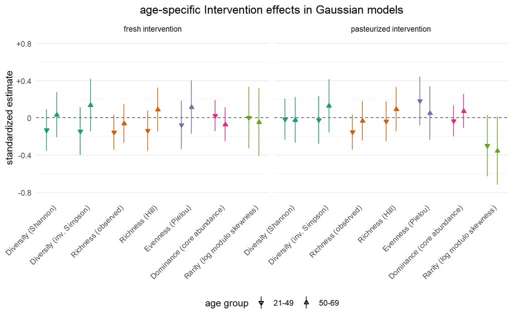

```r
# 1) effects of Gaussian models
ylim_gaussianInt <- c(-.8, .8)
plot_dat_ageInt <- results_dat_ageInt %>%
  filter(model_type  == "Gaussian") %>%
  mutate(parameter = factor(parameter, levels = c("interventionFresh", "interventionPasteurized"),
                            labels = c("fresh intervention", "pasteurized intervention")),
         model     = droplevels(model),
         model     = factor(model, levels = levels(model),
                            labels = levels(model) %>% gsub(pattern = " \\(Blood)", replacement = "")),
         model_xCoord = as.numeric(model) + xCoord_shift)

gg_gaussian_ageInt <- plot_dat_ageInt %>%
  ggplot(aes(x = model_xCoord, y = estimate_standardized, color = model_group, fill = model_group)) +
  geom_hline(yintercept = 0, linetype = 2, col = "gray30") +
  geom_pointrange(aes(ymin = CI_lower_standardized, ymax = CI_upper_standardized, shape = age_group), size = 0.25) +
  scale_x_continuous(breaks = 1:length(levels(plot_dat_ageInt$model)), labels = levels(plot_dat_ageInt$model)) +
  scale_y_continuous("standardized estimate", limits = ylim_gaussianInt,
                     breaks = c(-.8,-.4,0,.4,.8),
                     labels = c("-0.8", "-0.4", "0", "+0.4", "+0.8")) +
  scale_color_brewer(palette = "Dark2", guide = "none") +
  scale_fill_brewer(palette = "Dark2", guide = "none") +
  scale_shape_manual("age group", values = c(25,24)) +
  facet_wrap(~ parameter) +
  ggtitle("age-specific Intervention effects in Gaussian models") +
  theme(axis.text.x        = element_text(hjust = 1, angle = 45),
        axis.title.x       = element_blank(),
        panel.grid.minor.y = element_line(color = "gray96"),
        panel.grid.major.x = element_blank(),
        legend.position    = "bottom")
gg_gaussian_ageInt
```

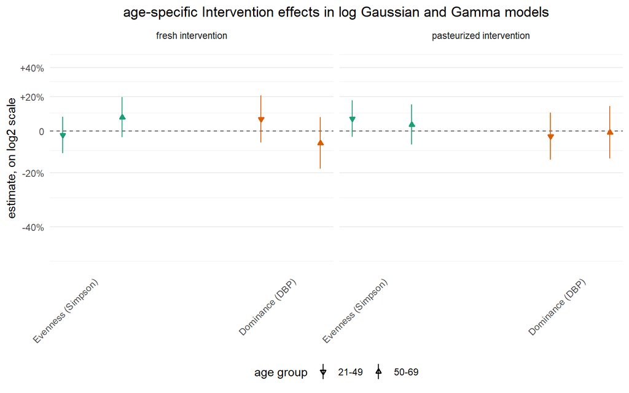

```r
# 2) effects of log Gaussian and Gamma models
ylim_logInt <- c(.5,1.5)
plot_dat_ageInt_exp <- results_dat_ageInt %>%
  filter(model_type  != "Gaussian") %>%
  mutate(parameter = factor(parameter, levels = c("interventionFresh", "interventionPasteurized"),
                            labels = c("fresh intervention", "pasteurized intervention")),
         model     = droplevels(model),
         model     = factor(model, levels = levels(model),
                            labels = levels(model) %>% gsub(pattern = " \\(Blood)", replacement = "")),
         model_xCoord = as.numeric(model) + xCoord_shift)

gg_exp_ageInt <- plot_dat_ageInt_exp %>%
  ggplot(aes(x = model_xCoord, y = exp_estimate, color = model_group, fill = model_group)) +
  geom_hline(yintercept = 1, linetype = 2, col = "gray30") +
  geom_pointrange(aes(ymin = exp_CIlower, ymax = exp_CIupper, shape = age_group), size = 0.25) +
  scale_x_continuous(breaks = 1:length(levels(plot_dat_ageInt_exp$model)), labels = levels(plot_dat_ageInt_exp$model)) +
  scale_y_continuous("estimate, on log2 scale", trans = "log2", limits = ylim_logInt,
                     breaks = c(.6, .8, 1, 1.2, 1.4),
                     labels = c("-40%", "-20%", "0", "+20%", "+40%"),
                     minor_breaks = c(.5, .7, .9, 1.1, 1.3, 1.5)) +
  scale_color_brewer(palette = "Dark2", guide = "none") +
  scale_fill_brewer(palette = "Dark2", guide = "none") +
  scale_shape_manual("age group", values = c(25,24)) +
  facet_wrap(~ parameter) +
  ggtitle("age-specific Intervention effects in log Gaussian and Gamma models") +
  theme(axis.text.x        = element_text(hjust = 1, angle = 45),
        axis.title.x       = element_blank(),
        panel.grid.minor.y = element_line(color = "gray96"),
        panel.grid.major.x = element_blank(),
        legend.position    = "bottom")
gg_exp_ageInt
```

## Interactions: Intervention by sex

```r
# create a results table with all effects
modelResults_sexInt_list <- lapply(names(model_names), function(x) {

  variable         <- model_names[x] %>% unname()
  model            <- model_sexInt_list[[x]][[1]]
  model_changedRef <- model_sexInt_list[[x]][[2]]
  model_type       <- modelType_list[[x]]

  log_wasApplied <- (model_type %in% c("Gamma", "log Gaussian"))

  results_dat1 <- summary(model)$p.table %>% as.data.frame() %>%
    mutate(parameter   = row.names(.)) %>%
    filter(grepl("intervention", parameter),
           !grepl(":", parameter)) %>%
    mutate(gender = levels(dat_model$gender)[1])
  results_dat2 <- summary(model_changedRef)$p.table %>% as.data.frame() %>%
    mutate(parameter   = row.names(.)) %>%
    filter(grepl("intervention", parameter),
           !grepl(":", parameter)) %>%
    mutate(gender = levels(dat_model$gender)[2])
  results_dat <- results_dat1 %>% dplyr::bind_rows(results_dat2) %>%
    dplyr::rename(estimate   = "Estimate",
                  se         = "Std. Error",
                  pvalue     = "Pr(>|t|)") %>%
    mutate(model      = x,
           model_type = model_type,
           CI_lower   = estimate - qnorm(0.975) * se,
           CI_upper   = estimate + qnorm(0.975) * se)

  if (!log_wasApplied) { # standardize the effects by the standard deviation of the respnse variable
    results_dat <- results_dat %>%
      mutate(y_sd = sd(dat_model[[variable]], na.rm = TRUE),
             estimate_standardized = estimate / y_sd,
             se_standardized       = se / y_sd,
             CI_lower_standardized = estimate_standardized - qnorm(0.975) * se_standardized,
             CI_upper_standardized = estimate_standardized + qnorm(0.975) * se_standardized)

  } else { # exponentiate the effects
    results_dat <- results_dat %>%
      mutate(exp_estimate = exp(estimate),
             exp_CIlower  = exp(CI_lower),
             exp_CIupper  = exp(CI_upper))
  }

  results_dat <- results_dat %>%
    select(model, model_type, gender, parameter, estimate, CI_lower, CI_upper, contains("standardized"), contains("exp"), pvalue)
  row.names(results_dat) <- NULL

  return(results_dat)
})
results_dat_sexInt <- modelResults_sexInt_list %>% bind_rows() %>%
  mutate(model        = factor(model, levels = names(model_names)),
         model_group  = sapply(as.character(model), function(x) { strsplit(x, split = " \\(")[[1]][1] }),
         model_group  = factor(model_group, levels = unique(model_group)),
         xCoord_shift = case_when(gender == min(gender) ~ -0.15,
                                  TRUE                  ~ 0.15))
```

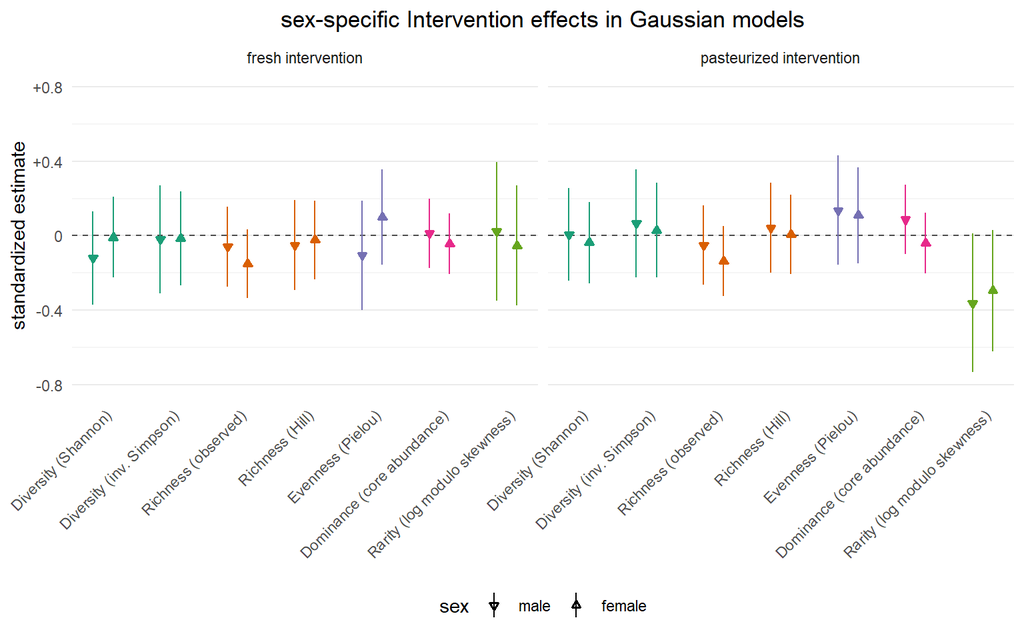

```r
# 1) effects of Gaussian models
ylim_gaussianInt <- c(-.8, .8)
plot_dat_sexInt <- results_dat_sexInt %>%
  filter(model_type  == "Gaussian") %>%
  mutate(parameter = factor(parameter, levels = c("interventionFresh", "interventionPasteurized"),
                            labels = c("fresh intervention", "pasteurized intervention")),
         gender    = factor(gender, levels = c("M", "W"), labels = c("male", "female")),
         model     = droplevels(model),
         model     = factor(model, levels = levels(model),
                            labels = levels(model) %>% gsub(pattern = " \\(Blood)", replacement = "")),
         model_xCoord = as.numeric(model) + xCoord_shift)

gg_gaussian_sexInt <- plot_dat_sexInt %>%
  ggplot(aes(x = model_xCoord, y = estimate_standardized, color = model_group, fill = model_group)) +
  geom_hline(yintercept = 0, linetype = 2, col = "gray30") +
  geom_pointrange(aes(ymin = CI_lower_standardized, ymax = CI_upper_standardized, shape = gender), size = 0.25) +
  scale_x_continuous(breaks = 1:length(levels(plot_dat_sexInt$model)), labels = levels(plot_dat_sexInt$model)) +
  scale_y_continuous("standardized estimate", limits = ylim_gaussianInt,
                     breaks = c(-.8,-.4,0,.4,.8),
                     labels = c("-0.8", "-0.4", "0", "+0.4", "+0.8")) +
  scale_color_brewer(palette = "Dark2", guide = "none") +
  scale_fill_brewer(palette = "Dark2", guide = "none") +
  scale_shape_manual("sex", values = c(25,24)) +
  facet_wrap(~ parameter) +
  ggtitle("sex-specific Intervention effects in Gaussian models") +
  theme(axis.text.x        = element_text(hjust = 1, angle = 45),
        axis.title.x       = element_blank(),
        panel.grid.minor.y = element_line(color = "gray96"),
        panel.grid.major.x = element_blank(),
        legend.position    = "bottom")
gg_gaussian_sexInt
```

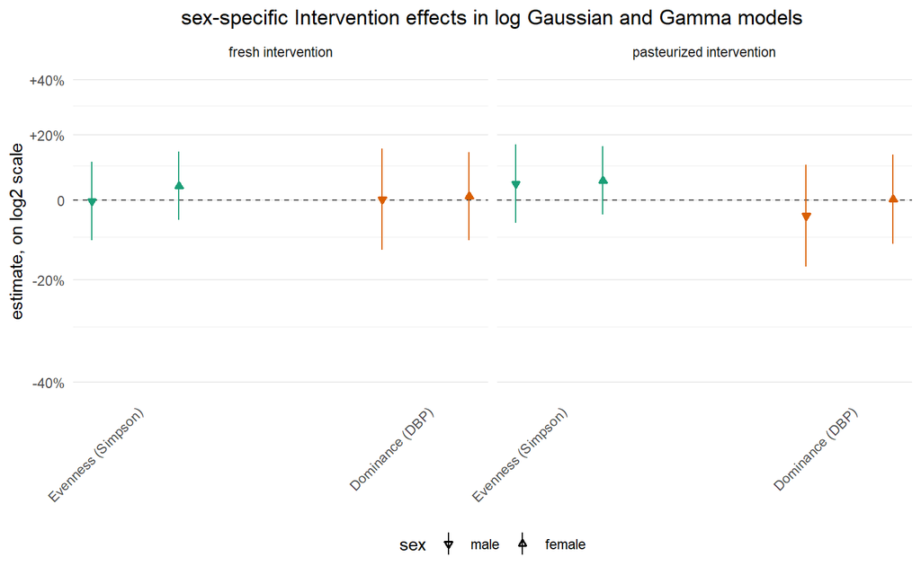

```r
# 2) effects of log Gaussian and Gamma models
ylim_logInt <- c(.6,1.4)
plot_dat_sexInt_exp <- results_dat_sexInt %>%
  filter(model_type  != "Gaussian") %>%
  mutate(parameter = factor(parameter, levels = c("interventionFresh", "interventionPasteurized"),
                            labels = c("fresh intervention", "pasteurized intervention")),
         gender    = factor(gender, levels = c("M", "W"), labels = c("male", "female")),
         model     = droplevels(model),
         model     = factor(model, levels = levels(model),
                            labels = levels(model) %>% gsub(pattern = " \\(Blood)", replacement = "")),
         model_xCoord = as.numeric(model) + xCoord_shift)

gg_exp_sexInt <- plot_dat_sexInt_exp %>%
  ggplot(aes(x = model_xCoord, y = exp_estimate, color = model_group, fill = model_group)) +
  geom_hline(yintercept = 1, linetype = 2, col = "gray30") +
  geom_pointrange(aes(ymin = exp_CIlower, ymax = exp_CIupper, shape = gender), size = 0.25) +
  scale_x_continuous(breaks = 1:length(levels(plot_dat_sexInt_exp$model)), labels = levels(plot_dat_sexInt_exp$model)) +
  scale_y_continuous("estimate, on log2 scale", trans = "log2", limits = ylim_logInt,
                     breaks = c(.6, .8, 1, 1.2, 1.4, 1.6),
                     labels = c("-40%", "-20%", "0", "+20%", "+40%", "+60%"),
                     minor_breaks = c(.5, .7, .9, 1.1, 1.3, 1.5)) +
  scale_color_brewer(palette = "Dark2", guide = "none") +
  scale_fill_brewer(palette = "Dark2", guide = "none") +
  scale_shape_manual("sex", values = c(25,24)) +
  facet_wrap(~ parameter) +
  ggtitle("sex-specific Intervention effects in log Gaussian and Gamma models") +
  theme(axis.text.x        = element_text(hjust = 1, angle = 45),
        axis.title.x       = element_blank(),
        panel.grid.minor.y = element_line(color = "gray96"),
        panel.grid.major.x = element_blank(),
        legend.position    = "bottom")
gg_exp_sexInt
```

## Interactions: Intervention by BMI

```r
# create a results table with all effects
modelResults_bmiInt_list <- lapply(names(model_names), function(x) {

  variable         <- model_names[x] %>% unname()
  model            <- model_bmiInt_list[[x]][[1]]
  model_changedRef <- model_bmiInt_list[[x]][[2]]
  model_type       <- modelType_list[[x]]

  log_wasApplied <- (model_type %in% c("Gamma", "log Gaussian"))

  results_dat1 <- summary(model)$p.table %>% as.data.frame() %>%
    mutate(parameter   = row.names(.)) %>%
    filter(grepl("intervention", parameter),
           !grepl(":", parameter)) %>%
    mutate(bmi_group = levels(dat_model$bmi_cat)[1])
  results_dat2 <- summary(model_changedRef)$p.table %>% as.data.frame() %>%
    mutate(parameter   = row.names(.)) %>%
    filter(grepl("intervention", parameter),
           !grepl(":", parameter)) %>%
    mutate(bmi_group = levels(dat_model$bmi_cat)[2])
  results_dat <- results_dat1 %>% dplyr::bind_rows(results_dat2) %>%
    dplyr::rename(estimate   = "Estimate",
                  se         = "Std. Error",
                  pvalue     = "Pr(>|t|)") %>%
    mutate(model      = x,
           model_type = model_type,
           CI_lower   = estimate - qnorm(0.975) * se,
           CI_upper   = estimate + qnorm(0.975) * se)

  if (!log_wasApplied) { # standardize the effects by the standard deviation of the respnse variable
    results_dat <- results_dat %>%
      mutate(y_sd = sd(dat_model[[variable]], na.rm = TRUE),
             estimate_standardized = estimate / y_sd,
             se_standardized       = se / y_sd,
             CI_lower_standardized = estimate_standardized - qnorm(0.975) * se_standardized,
             CI_upper_standardized = estimate_standardized + qnorm(0.975) * se_standardized)

  } else { # exponentiate the effects
    results_dat <- results_dat %>%
      mutate(exp_estimate = exp(estimate),
             exp_CIlower  = exp(CI_lower),
             exp_CIupper  = exp(CI_upper))
  }

  results_dat <- results_dat %>%
    select(model, model_type, bmi_group, parameter, estimate, CI_lower, CI_upper, contains("standardized"), contains("exp"), pvalue)
  row.names(results_dat) <- NULL

  return(results_dat)
})
results_dat_bmiInt <- modelResults_bmiInt_list %>% bind_rows() %>%
  mutate(model       = factor(model, levels = names(model_names)),
         model_group  = sapply(as.character(model), function(x) { strsplit(x, split = " \\(")[[1]][1] }),
         model_group  = factor(model_group, levels = unique(model_group)),
         xCoord_shift = case_when(bmi_group == min(bmi_group) ~ -0.15,
                                  TRUE                        ~ 0.15))
```

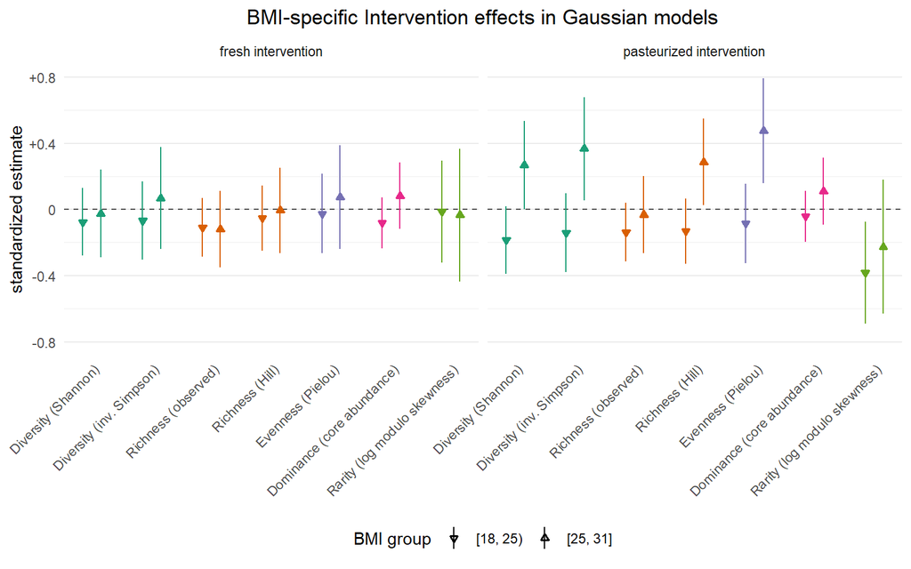

```r
# 1) effects of Gaussian models
ylim_gaussianInt <- c(-.8, .8)
plot_dat_bmiInt <- results_dat_bmiInt %>%
  filter(model_type  == "Gaussian") %>%
  mutate(parameter = factor(parameter, levels = c("interventionFresh", "interventionPasteurized"),
                            labels = c("fresh intervention", "pasteurized intervention")),
         model     = droplevels(model),
         model     = factor(model, levels = levels(model),
                            labels = levels(model) %>% gsub(pattern = " \\(Blood)", replacement = "")),
         model_xCoord = as.numeric(model) + xCoord_shift)

gg_gaussian_bmiInt <- plot_dat_bmiInt %>%
  ggplot(aes(x = model_xCoord, y = estimate_standardized, color = model_group, fill = model_group)) +
  geom_hline(yintercept = 0, linetype = 2, col = "gray30") +
  geom_pointrange(aes(ymin = CI_lower_standardized, ymax = CI_upper_standardized, shape = bmi_group), size = 0.25) +
  scale_x_continuous(breaks = 1:length(levels(plot_dat_bmiInt$model)), labels = levels(plot_dat_bmiInt$model)) +
  scale_y_continuous("standardized estimate", limits = ylim_gaussianInt,
                     breaks = c(-.8,-.4,0,.4,.8),
                     labels = c("-0.8", "-0.4", "0", "+0.4", "+0.8")) +
  scale_color_brewer(palette = "Dark2", guide = "none") +
  scale_fill_brewer(palette = "Dark2", guide = "none") +
  scale_shape_manual("BMI group", values = c(25,24)) +
  facet_wrap(~ parameter) +
  ggtitle("BMI-specific Intervention effects in Gaussian models") +
  theme(axis.text.x        = element_text(hjust = 1, angle = 45),
        axis.title.x       = element_blank(),
        panel.grid.minor.y = element_line(color = "gray96"),
        panel.grid.major.x = element_blank(),
        legend.position    = "bottom")
gg_gaussian_bmiInt
```

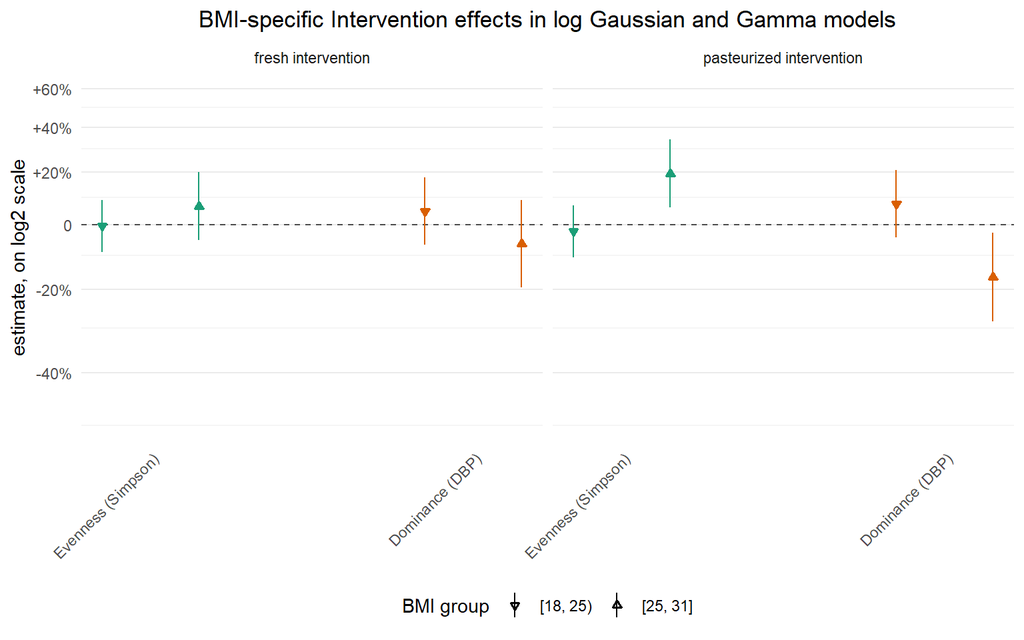

```r
# 2) effects of log Gaussian and Gamma models
ylim_logInt <- c(.5,1.6)
plot_dat_bmiInt_exp <- results_dat_bmiInt %>%
  filter(model_type  != "Gaussian") %>%
  mutate(parameter = factor(parameter, levels = c("interventionFresh", "interventionPasteurized"),
                            labels = c("fresh intervention", "pasteurized intervention")),
         model     = droplevels(model),
         model     = factor(model, levels = levels(model),
                            labels = levels(model) %>% gsub(pattern = " \\(Blood)", replacement = "")),
         model_xCoord = as.numeric(model) + xCoord_shift)

gg_exp_bmiInt <- plot_dat_bmiInt_exp %>%
  ggplot(aes(x = model_xCoord, y = exp_estimate, color = model_group, fill = model_group)) +
  geom_hline(yintercept = 1, linetype = 2, col = "gray30") +
  geom_pointrange(aes(ymin = exp_CIlower, ymax = exp_CIupper, shape = bmi_group), size = 0.25) +
  scale_x_continuous(breaks = 1:length(levels(plot_dat_bmiInt_exp$model)), labels = levels(plot_dat_bmiInt_exp$model)) +
  scale_y_continuous("estimate, on log2 scale", trans = "log2", limits = ylim_logInt,
                     breaks = c(.6, .8, 1, 1.2, 1.4, 1.6, 1.8, 2),
                     labels = c("-40%", "-20%", "0", "+20%", "+40%", "+60%", "+80%", "+100%"),
                     minor_breaks = c(.5, .7, .9, 1.1, 1.3, 1.5, 1.7, 1.9)) +
  scale_color_brewer(palette = "Dark2", guide = "none") +
  scale_fill_brewer(palette = "Dark2", guide = "none") +
  scale_shape_manual("BMI group", values = c(25,24)) +
  facet_wrap(~ parameter) +
  ggtitle("BMI-specific Intervention effects in log Gaussian and Gamma models") +
  theme(axis.text.x        = element_text(hjust = 1, angle = 45),
        axis.title.x       = element_blank(),
        panel.grid.minor.y = element_line(color = "gray96"),
        panel.grid.major.x = element_blank(),
        legend.position    = "bottom")
gg_exp_bmiInt
```

## Interactions: Intervention by fiber

```r
# create a results table with all effects
modelResults_fibInt_list <- lapply(names(model_names), function(x) {

  variable         <- model_names[x] %>% unname()
  model            <- model_fibInt_list[[x]][[1]]
  model_changedRef <- model_fibInt_list[[x]][[2]]
  model_type       <- modelType_list[[x]]

  log_wasApplied <- (model_type %in% c("Gamma", "log Gaussian"))

  results_dat1 <- summary(model)$p.table %>% as.data.frame() %>%
    mutate(parameter   = row.names(.)) %>%
    filter(grepl("intervention", parameter),
           !grepl(":", parameter)) %>%
    mutate(fib_group = levels(dat_model$dailyFiber_cat)[1])
  results_dat2 <- summary(model_changedRef)$p.table %>% as.data.frame() %>%
    mutate(parameter   = row.names(.)) %>%
    filter(grepl("intervention", parameter),
           !grepl(":", parameter)) %>%
    mutate(fib_group = levels(dat_model$dailyFiber_cat)[2])
  results_dat <- results_dat1 %>% dplyr::bind_rows(results_dat2) %>%
    dplyr::rename(estimate   = "Estimate",
                  se         = "Std. Error",
                  pvalue     = "Pr(>|t|)") %>%
    mutate(model      = x,
           model_type = model_type,
           CI_lower   = estimate - qnorm(0.975) * se,
           CI_upper   = estimate + qnorm(0.975) * se)

  if (!log_wasApplied) { # standardize the effects by the standard deviation of the respnse variable
    results_dat <- results_dat %>%
      mutate(y_sd = sd(dat_model[[variable]], na.rm = TRUE),
             estimate_standardized = estimate / y_sd,
             se_standardized       = se / y_sd,
             CI_lower_standardized = estimate_standardized - qnorm(0.975) * se_standardized,
             CI_upper_standardized = estimate_standardized + qnorm(0.975) * se_standardized)

  } else { # exponentiate the effects
    results_dat <- results_dat %>%
      mutate(exp_estimate = exp(estimate),
             exp_CIlower  = exp(CI_lower),
             exp_CIupper  = exp(CI_upper))
  }

  results_dat <- results_dat %>%
    select(model, model_type, fib_group, parameter, estimate, CI_lower, CI_upper, contains("standardized"), contains("exp"), pvalue)
  row.names(results_dat) <- NULL

  return(results_dat)
})
results_dat_fibInt <- modelResults_fibInt_list %>% bind_rows() %>%
  mutate(model       = factor(model, levels = names(model_names)),
         model_group  = sapply(as.character(model), function(x) { strsplit(x, split = " \\(")[[1]][1] }),
         model_group  = factor(model_group, levels = unique(model_group)),
         xCoord_shift = case_when(fib_group == min(fib_group) ~ -0.15,
                                  TRUE                        ~ 0.15))
```

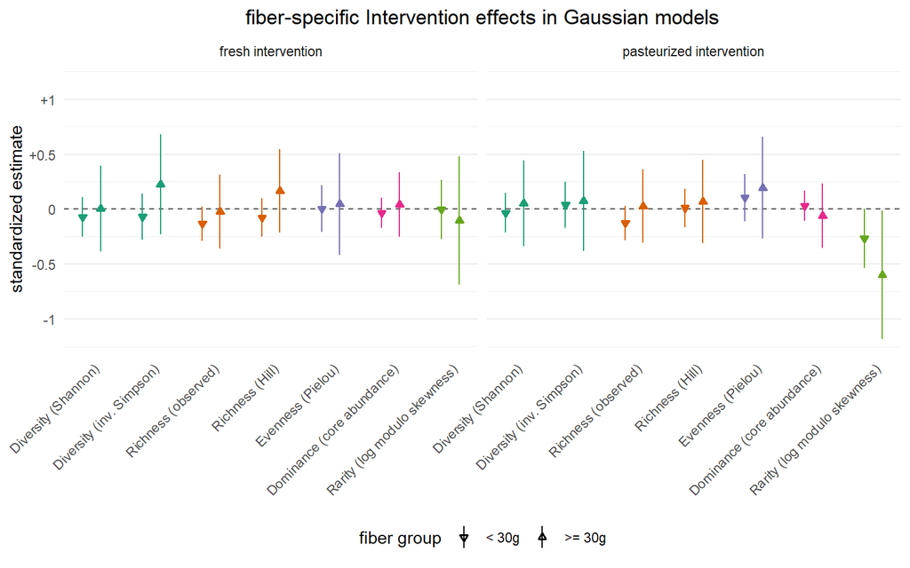

```r
# 1) effects of Gaussian models
ylim_gaussianInt <- c(-1.2, 1.2)
plot_dat_fibInt <- results_dat_fibInt %>%
  filter(model_type  == "Gaussian") %>%
  mutate(parameter = factor(parameter, levels = c("interventionFresh", "interventionPasteurized"),
                            labels = c("fresh intervention", "pasteurized intervention")),
         model     = droplevels(model),
         model     = factor(model, levels = levels(model),
                            labels = levels(model) %>% gsub(pattern = " \\(Blood)", replacement = "")),
         model_xCoord = as.numeric(model) + xCoord_shift)

gg_gaussian_fibInt <- plot_dat_fibInt %>%
  ggplot(aes(x = model_xCoord, y = estimate_standardized, color = model_group, fill = model_group)) +
  geom_hline(yintercept = 0, linetype = 2, col = "gray30") +
  geom_pointrange(aes(ymin = CI_lower_standardized, ymax = CI_upper_standardized, shape = fib_group), size = 0.25) +
  scale_x_continuous(breaks = 1:length(levels(plot_dat_fibInt$model)), labels = levels(plot_dat_fibInt$model)) +
  scale_y_continuous("standardized estimate", limits = ylim_gaussianInt,
                     breaks = c(-1,-.5,0,.5,1),
                     labels = c("-1", "-0.5", "0", "+0.5", "+1")) +
  scale_color_brewer(palette = "Dark2", guide = "none") +
  scale_fill_brewer(palette = "Dark2", guide = "none") +
  scale_shape_manual("fiber group", values = c(25,24)) +
  facet_wrap(~ parameter) +
  ggtitle("fiber-specific Intervention effects in Gaussian models") +
  theme(axis.text.x        = element_text(hjust = 1, angle = 45),
        axis.title.x       = element_blank(),
        panel.grid.minor.y = element_line(color = "gray96"),
        panel.grid.major.x = element_blank(),
        legend.position    = "bottom")
gg_gaussian_fibInt
```

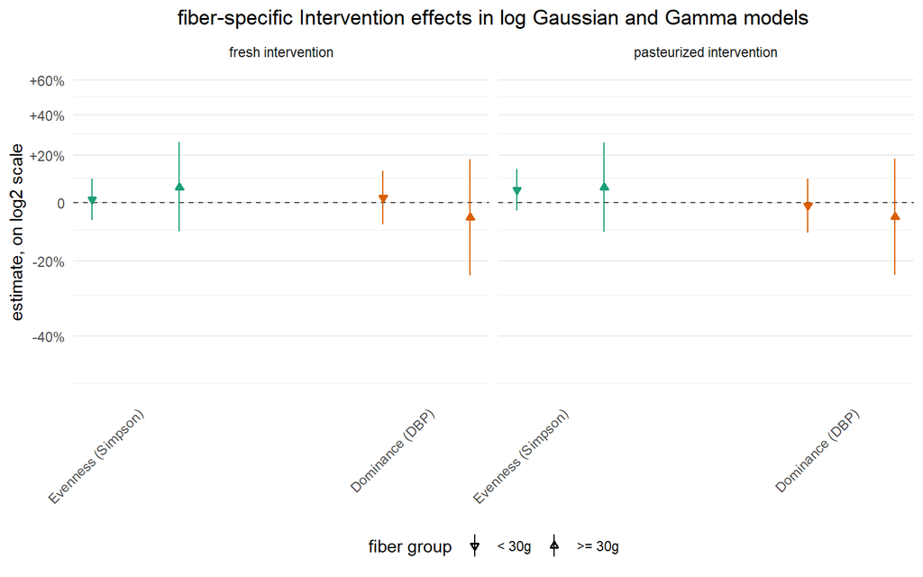

```r
# 2) effects of log Gaussian and Gamma models
ylim_logInt <- c(.5,1.6)
plot_dat_fibInt_exp <- results_dat_fibInt %>%
  filter(model_type  != "Gaussian") %>%
  mutate(parameter = factor(parameter, levels = c("interventionFresh", "interventionPasteurized"),
                            labels = c("fresh intervention", "pasteurized intervention")),
         model     = droplevels(model),
         model     = factor(model, levels = levels(model),
                            labels = levels(model) %>% gsub(pattern = " \\(Blood)", replacement = "")),
         model_xCoord = as.numeric(model) + xCoord_shift)

gg_exp_fibInt <- plot_dat_fibInt_exp %>%
  ggplot(aes(x = model_xCoord, y = exp_estimate, color = model_group, fill = model_group)) +
  geom_hline(yintercept = 1, linetype = 2, col = "gray30") +
  geom_pointrange(aes(ymin = exp_CIlower, ymax = exp_CIupper, shape = fib_group), size = 0.25) +
  scale_x_continuous(breaks = 1:length(levels(plot_dat_fibInt_exp$model)), labels = levels(plot_dat_fibInt_exp$model)) +
  scale_y_continuous("estimate, on log2 scale", trans = "log2", limits = ylim_logInt,
                     breaks = c(.6, .8, 1, 1.2, 1.4, 1.6, 1.8, 2),
                     labels = c("-40%", "-20%", "0", "+20%", "+40%", "+60%", "+80%", "+100%"),
                     minor_breaks = c(.5, .7, .9, 1.1, 1.3, 1.5, 1.7, 1.9)) +
  scale_color_brewer(palette = "Dark2", guide = "none") +
  scale_fill_brewer(palette = "Dark2", guide = "none") +
  scale_shape_manual("fiber group", values = c(25,24)) +
  facet_wrap(~ parameter) +
  ggtitle("fiber-specific Intervention effects in log Gaussian and Gamma models") +
  theme(axis.text.x        = element_text(hjust = 1, angle = 45),
        axis.title.x       = element_blank(),
        panel.grid.minor.y = element_line(color = "gray96"),
        panel.grid.major.x = element_blank(),
        legend.position    = "bottom")
gg_exp_fibInt
```

# Corrected p-values for interaction effects

For the interaction effects, correct for multiple testing by applying the Benjamini-Hochberg correction. The correction is applied individually, once for the sex / the age / the BMI interaction models.

```r
# sex
results_dat_sexInt <- results_dat_sexInt %>%
  mutate(pvalue_corrected   = p.adjust(pvalue, method = "BH") %>% round(4),
         pvalue_significant = ifelse(pvalue_corrected < 0.05, "yes", "no"))

results_dat_sexInt %>%
  select(model, model_type, gender, parameter, pvalue_corrected, pvalue_significant) %>%
  kable() %>%
  kable_styling()
```

| model | model_type | gender | parameter | pvalue_corrected | pvalue_significant |
| --- | --- | --- | --- | --- | --- |
| Diversity (Shannon) | Gaussian | M | interventionFresh | 0.9761 | no |
| Diversity (Shannon) | Gaussian | M | interventionPasteurized | 0.9761 | no |
| Diversity (Shannon) | Gaussian | W | interventionFresh | 0.9761 | no |
| Diversity (Shannon) | Gaussian | W | interventionPasteurized | 0.9761 | no |
| Diversity (inv. Simpson) | Gaussian | M | interventionFresh | 0.9761 | no |
| Diversity (inv. Simpson) | Gaussian | M | interventionPasteurized | 0.9761 | no |
| Diversity (inv. Simpson) | Gaussian | W | interventionFresh | 0.9761 | no |
| Diversity (inv. Simpson) | Gaussian | W | interventionPasteurized | 0.9761 | no |
| Richness (observed) | Gaussian | M | interventionFresh | 0.9761 | no |
| Richness (observed) | Gaussian | M | interventionPasteurized | 0.9761 | no |
| Richness (observed) | Gaussian | W | interventionFresh | 0.9761 | no |
| Richness (observed) | Gaussian | W | interventionPasteurized | 0.9761 | no |
| Richness (Hill) | Gaussian | M | interventionFresh | 0.9761 | no |
| Richness (Hill) | Gaussian | M | interventionPasteurized | 0.9761 | no |
| Richness (Hill) | Gaussian | W | interventionFresh | 0.9761 | no |
| Richness (Hill) | Gaussian | W | interventionPasteurized | 0.9761 | no |
| Evenness (Pielou) | Gaussian | M | interventionFresh | 0.9761 | no |
| Evenness (Pielou) | Gaussian | M | interventionPasteurized | 0.9761 | no |
| Evenness (Pielou) | Gaussian | W | interventionFresh | 0.9761 | no |
| Evenness (Pielou) | Gaussian | W | interventionPasteurized | 0.9761 | no |
| Evenness (Simpson) | log Gaussian | M | interventionFresh | 0.9761 | no |
| Evenness (Simpson) | log Gaussian | M | interventionPasteurized | 0.9761 | no |
| Evenness (Simpson) | log Gaussian | W | interventionFresh | 0.9761 | no |
| Evenness (Simpson) | log Gaussian | W | interventionPasteurized | 0.9761 | no |
| Dominance (DBP) | Gamma | M | interventionFresh | 0.9761 | no |
| Dominance (DBP) | Gamma | M | interventionPasteurized | 0.9761 | no |
| Dominance (DBP) | Gamma | W | interventionFresh | 0.9761 | no |
| Dominance (DBP) | Gamma | W | interventionPasteurized | 0.9761 | no |
| Dominance (core abundance) | Gaussian | M | interventionFresh | 0.9761 | no |
| Dominance (core abundance) | Gaussian | M | interventionPasteurized | 0.9761 | no |
| Dominance (core abundance) | Gaussian | W | interventionFresh | 0.9761 | no |
| Dominance (core abundance) | Gaussian | W | interventionPasteurized | 0.9761 | no |
| Rarity (log modulo skewness) | Gaussian | M | interventionFresh | 0.9761 | no |
| Rarity (log modulo skewness) | Gaussian | M | interventionPasteurized | 0.9761 | no |
| Rarity (log modulo skewness) | Gaussian | W | interventionFresh | 0.9761 | no |
| Rarity (log modulo skewness) | Gaussian | W | interventionPasteurized | 0.9761 | no |

```r
# age
results_dat_ageInt <- results_dat_ageInt %>%
  mutate(pvalue_corrected   = p.adjust(pvalue, method = "BH") %>% round(4),
         pvalue_significant = ifelse(pvalue_corrected < 0.05, "yes", "no"))

results_dat_ageInt %>%
  select(model, model_type, age_group, parameter, pvalue_corrected, pvalue_significant) %>%
  kable() %>%
  kable_styling()
```

| model | model_type | age_group | parameter | pvalue_corrected | pvalue_significant |
| --- | --- | --- | --- | --- | --- |
| Diversity (Shannon) | Gaussian | 21-49 | interventionFresh | 0.8729 | no |
| Diversity (Shannon) | Gaussian | 21-49 | interventionPasteurized | 0.9435 | no |
| Diversity (Shannon) | Gaussian | 50-69 | interventionFresh | 0.9317 | no |
| Diversity (Shannon) | Gaussian | 50-69 | interventionPasteurized | 0.9435 | no |
| Diversity (inv. Simpson) | Gaussian | 21-49 | interventionFresh | 0.8729 | no |
| Diversity (inv. Simpson) | Gaussian | 21-49 | interventionPasteurized | 0.9435 | no |
| Diversity (inv. Simpson) | Gaussian | 50-69 | interventionFresh | 0.8729 | no |
| Diversity (inv. Simpson) | Gaussian | 50-69 | interventionPasteurized | 0.8729 | no |
| Richness (observed) | Gaussian | 21-49 | interventionFresh | 0.8729 | no |
| Richness (observed) | Gaussian | 21-49 | interventionPasteurized | 0.8729 | no |
| Richness (observed) | Gaussian | 50-69 | interventionFresh | 0.9317 | no |
| Richness (observed) | Gaussian | 50-69 | interventionPasteurized | 0.9317 | no |
| Richness (Hill) | Gaussian | 21-49 | interventionFresh | 0.8729 | no |
| Richness (Hill) | Gaussian | 21-49 | interventionPasteurized | 0.9317 | no |
| Richness (Hill) | Gaussian | 50-69 | interventionFresh | 0.8729 | no |
| Richness (Hill) | Gaussian | 50-69 | interventionPasteurized | 0.8729 | no |
| Evenness (Pielou) | Gaussian | 21-49 | interventionFresh | 0.9317 | no |
| Evenness (Pielou) | Gaussian | 21-49 | interventionPasteurized | 0.8729 | no |
| Evenness (Pielou) | Gaussian | 50-69 | interventionFresh | 0.8729 | no |
| Evenness (Pielou) | Gaussian | 50-69 | interventionPasteurized | 0.9317 | no |
| Evenness (Simpson) | log Gaussian | 21-49 | interventionFresh | 0.9317 | no |
| Evenness (Simpson) | log Gaussian | 21-49 | interventionPasteurized | 0.8729 | no |
| Evenness (Simpson) | log Gaussian | 50-69 | interventionFresh | 0.8729 | no |
| Evenness (Simpson) | log Gaussian | 50-69 | interventionPasteurized | 0.9317 | no |
| Dominance (DBP) | Gamma | 21-49 | interventionFresh | 0.8729 | no |
| Dominance (DBP) | Gamma | 21-49 | interventionPasteurized | 0.9317 | no |
| Dominance (DBP) | Gamma | 50-69 | interventionFresh | 0.8729 | no |
| Dominance (DBP) | Gamma | 50-69 | interventionPasteurized | 0.9435 | no |
| Dominance (core abundance) | Gaussian | 21-49 | interventionFresh | 0.9317 | no |
| Dominance (core abundance) | Gaussian | 21-49 | interventionPasteurized | 0.9317 | no |
| Dominance (core abundance) | Gaussian | 50-69 | interventionFresh | 0.8729 | no |
| Dominance (core abundance) | Gaussian | 50-69 | interventionPasteurized | 0.8729 | no |
| Rarity (log modulo skewness) | Gaussian | 21-49 | interventionFresh | 0.9885 | no |
| Rarity (log modulo skewness) | Gaussian | 21-49 | interventionPasteurized | 0.8729 | no |
| Rarity (log modulo skewness) | Gaussian | 50-69 | interventionFresh | 0.9317 | no |
| Rarity (log modulo skewness) | Gaussian | 50-69 | interventionPasteurized | 0.8729 | no |

```r
# BMI
results_dat_bmiInt <- results_dat_bmiInt %>%
  mutate(pvalue_corrected   = p.adjust(pvalue, method = "BH") %>% round(4),
         pvalue_significant = ifelse(pvalue_corrected < 0.05, "yes", "no"))

results_dat_bmiInt %>%
  select(model, model_type, bmi_group, parameter, pvalue_corrected, pvalue_significant) %>%
  kable() %>%
  kable_styling()
```

| model | model_type | bmi_group | parameter | pvalue_corrected | pvalue_significant |
| --- | --- | --- | --- | --- | --- |
| Diversity (Shannon) | Gaussian | [18, 25) | interventionFresh | 0.7774 | no |
| Diversity (Shannon) | Gaussian | [18, 25) | interventionPasteurized | 0.3479 | no |
| Diversity (Shannon) | Gaussian | [25, 31] | interventionFresh | 0.9508 | no |
| Diversity (Shannon) | Gaussian | [25, 31] | interventionPasteurized | 0.2580 | no |
| Diversity (inv. Simpson) | Gaussian | [18, 25) | interventionFresh | 0.8167 | no |
| Diversity (inv. Simpson) | Gaussian | [18, 25) | interventionPasteurized | 0.6305 | no |
| Diversity (inv. Simpson) | Gaussian | [25, 31] | interventionFresh | 0.8167 | no |
| Diversity (inv. Simpson) | Gaussian | [25, 31] | interventionPasteurized | 0.1553 | no |
| Richness (observed) | Gaussian | [18, 25) | interventionFresh | 0.6305 | no |
| Richness (observed) | Gaussian | [18, 25) | interventionPasteurized | 0.5145 | no |
| Richness (observed) | Gaussian | [25, 31] | interventionFresh | 0.6305 | no |
| Richness (observed) | Gaussian | [25, 31] | interventionPasteurized | 0.9508 | no |
| Richness (Hill) | Gaussian | [18, 25) | interventionFresh | 0.8167 | no |
| Richness (Hill) | Gaussian | [18, 25) | interventionPasteurized | 0.6305 | no |
| Richness (Hill) | Gaussian | [25, 31] | interventionFresh | 0.9732 | no |
| Richness (Hill) | Gaussian | [25, 31] | interventionPasteurized | 0.1848 | no |
| Evenness (Pielou) | Gaussian | [18, 25) | interventionFresh | 0.9508 | no |
| Evenness (Pielou) | Gaussian | [18, 25) | interventionPasteurized | 0.7776 | no |
| Evenness (Pielou) | Gaussian | [25, 31] | interventionFresh | 0.8167 | no |
| Evenness (Pielou) | Gaussian | [25, 31] | interventionPasteurized | 0.0613 | no |
| Evenness (Simpson) | log Gaussian | [18, 25) | interventionFresh | 0.9689 | no |
| Evenness (Simpson) | log Gaussian | [18, 25) | interventionPasteurized | 0.8167 | no |
| Evenness (Simpson) | log Gaussian | [25, 31] | interventionFresh | 0.6305 | no |
| Evenness (Simpson) | log Gaussian | [25, 31] | interventionPasteurized | 0.0613 | no |
| Dominance (DBP) | Gamma | [18, 25) | interventionFresh | 0.7181 | no |
| Dominance (DBP) | Gamma | [18, 25) | interventionPasteurized | 0.6305 | no |
| Dominance (DBP) | Gamma | [25, 31] | interventionFresh | 0.7181 | no |
| Dominance (DBP) | Gamma | [25, 31] | interventionPasteurized | 0.1553 | no |
| Dominance (core abundance) | Gaussian | [18, 25) | interventionFresh | 0.6305 | no |
| Dominance (core abundance) | Gaussian | [18, 25) | interventionPasteurized | 0.8167 | no |
| Dominance (core abundance) | Gaussian | [25, 31] | interventionFresh | 0.7181 | no |
| Dominance (core abundance) | Gaussian | [25, 31] | interventionPasteurized | 0.6305 | no |
| Rarity (log modulo skewness) | Gaussian | [18, 25) | interventionFresh | 0.9689 | no |
| Rarity (log modulo skewness) | Gaussian | [18, 25) | interventionPasteurized | 0.1553 | no |
| Rarity (log modulo skewness) | Gaussian | [25, 31] | interventionFresh | 0.9508 | no |
| Rarity (log modulo skewness) | Gaussian | [25, 31] | interventionPasteurized | 0.6305 | no |

```r
# fiber
results_dat_fibInt <- results_dat_fibInt %>%
  mutate(pvalue_corrected   = p.adjust(pvalue, method = "BH") %>% round(4),
         pvalue_significant = ifelse(pvalue_corrected < 0.05, "yes", "no"))

results_dat_fibInt %>%
  select(model, model_type, fib_group, parameter, pvalue_corrected, pvalue_significant) %>%
  kable() %>%
  kable_styling()
```

| model | model_type | fib_group | parameter | pvalue_corrected | pvalue_significant |
| --- | --- | --- | --- | --- | --- |
| Diversity (Shannon) | Gaussian | < 30g | interventionFresh | 0.9883 | no |
| Diversity (Shannon) | Gaussian | < 30g | interventionPasteurized | 0.9883 | no |
| Diversity (Shannon) | Gaussian | >= 30g | interventionFresh | 0.9883 | no |
| Diversity (Shannon) | Gaussian | >= 30g | interventionPasteurized | 0.9883 | no |
| Diversity (inv. Simpson) | Gaussian | < 30g | interventionFresh | 0.9883 | no |
| Diversity (inv. Simpson) | Gaussian | < 30g | interventionPasteurized | 0.9883 | no |
| Diversity (inv. Simpson) | Gaussian | >= 30g | interventionFresh | 0.9883 | no |
| Diversity (inv. Simpson) | Gaussian | >= 30g | interventionPasteurized | 0.9883 | no |
| Richness (observed) | Gaussian | < 30g | interventionFresh | 0.9883 | no |
| Richness (observed) | Gaussian | < 30g | interventionPasteurized | 0.9883 | no |
| Richness (observed) | Gaussian | >= 30g | interventionFresh | 0.9883 | no |
| Richness (observed) | Gaussian | >= 30g | interventionPasteurized | 0.9883 | no |
| Richness (Hill) | Gaussian | < 30g | interventionFresh | 0.9883 | no |
| Richness (Hill) | Gaussian | < 30g | interventionPasteurized | 0.9883 | no |
| Richness (Hill) | Gaussian | >= 30g | interventionFresh | 0.9883 | no |
| Richness (Hill) | Gaussian | >= 30g | interventionPasteurized | 0.9883 | no |
| Evenness (Pielou) | Gaussian | < 30g | interventionFresh | 0.9883 | no |
| Evenness (Pielou) | Gaussian | < 30g | interventionPasteurized | 0.9883 | no |
| Evenness (Pielou) | Gaussian | >= 30g | interventionFresh | 0.9883 | no |
| Evenness (Pielou) | Gaussian | >= 30g | interventionPasteurized | 0.9883 | no |
| Evenness (Simpson) | log Gaussian | < 30g | interventionFresh | 0.9883 | no |
| Evenness (Simpson) | log Gaussian | < 30g | interventionPasteurized | 0.9883 | no |
| Evenness (Simpson) | log Gaussian | >= 30g | interventionFresh | 0.9883 | no |
| Evenness (Simpson) | log Gaussian | >= 30g | interventionPasteurized | 0.9883 | no |
| Dominance (DBP) | Gamma | < 30g | interventionFresh | 0.9883 | no |
| Dominance (DBP) | Gamma | < 30g | interventionPasteurized | 0.9883 | no |
| Dominance (DBP) | Gamma | >= 30g | interventionFresh | 0.9883 | no |
| Dominance (DBP) | Gamma | >= 30g | interventionPasteurized | 0.9883 | no |
| Dominance (core abundance) | Gaussian | < 30g | interventionFresh | 0.9883 | no |
| Dominance (core abundance) | Gaussian | < 30g | interventionPasteurized | 0.9883 | no |
| Dominance (core abundance) | Gaussian | >= 30g | interventionFresh | 0.9883 | no |
| Dominance (core abundance) | Gaussian | >= 30g | interventionPasteurized | 0.9883 | no |
| Rarity (log modulo skewness) | Gaussian | < 30g | interventionFresh | 0.9883 | no |
| Rarity (log modulo skewness) | Gaussian | < 30g | interventionPasteurized | 0.9883 | no |
| Rarity (log modulo skewness) | Gaussian | >= 30g | interventionFresh | 0.9883 | no |
| Rarity (log modulo skewness) | Gaussian | >= 30g | interventionPasteurized | 0.9883 | no |

```r
# baseline diversity
results_dat_divInt <- results_dat_divInt %>%
  mutate(pvalue_corrected   = p.adjust(pvalue, method = "BH") %>% round(4),
         pvalue_significant = ifelse(pvalue_corrected < 0.05, "yes", "no"))

results_dat_divInt %>%
  select(model, model_type, div_group, parameter, pvalue_corrected, pvalue_significant) %>%
  kable() %>%
  kable_styling()
```

| model | model_type | div_group | parameter | pvalue_corrected | pvalue_significant |
| --- | --- | --- | --- | --- | --- |
| Diversity (Shannon) | Gaussian | [2.8, 3.85) | interventionFresh | 0.9839 | no |
| Diversity (Shannon) | Gaussian | [2.8, 3.85) | interventionPasteurized | 0.9220 | no |
| Diversity (Shannon) | Gaussian | [3.85, 4.4) | interventionFresh | 0.9220 | no |
| Diversity (Shannon) | Gaussian | [3.85, 4.4) | interventionPasteurized | 0.9173 | no |
| Diversity (inv. Simpson) | Gaussian | [2.8, 3.85) | interventionFresh | 0.9220 | no |
| Diversity (inv. Simpson) | Gaussian | [2.8, 3.85) | interventionPasteurized | 0.9173 | no |
| Diversity (inv. Simpson) | Gaussian | [3.85, 4.4) | interventionFresh | 0.9220 | no |
| Diversity (inv. Simpson) | Gaussian | [3.85, 4.4) | interventionPasteurized | 0.9220 | no |
| Richness (observed) | Gaussian | [2.8, 3.85) | interventionFresh | 0.9173 | no |
| Richness (observed) | Gaussian | [2.8, 3.85) | interventionPasteurized | 0.9839 | no |
| Richness (observed) | Gaussian | [3.85, 4.4) | interventionFresh | 0.9173 | no |
| Richness (observed) | Gaussian | [3.85, 4.4) | interventionPasteurized | 0.7202 | no |
| Richness (Hill) | Gaussian | [2.8, 3.85) | interventionFresh | 0.9340 | no |
| Richness (Hill) | Gaussian | [2.8, 3.85) | interventionPasteurized | 0.9173 | no |
| Richness (Hill) | Gaussian | [3.85, 4.4) | interventionFresh | 0.9220 | no |
| Richness (Hill) | Gaussian | [3.85, 4.4) | interventionPasteurized | 0.9173 | no |
| Evenness (Pielou) | Gaussian | [2.8, 3.85) | interventionFresh | 0.9220 | no |
| Evenness (Pielou) | Gaussian | [2.8, 3.85) | interventionPasteurized | 0.9173 | no |
| Evenness (Pielou) | Gaussian | [3.85, 4.4) | interventionFresh | 0.9340 | no |
| Evenness (Pielou) | Gaussian | [3.85, 4.4) | interventionPasteurized | 0.9340 | no |
| Evenness (Simpson) | log Gaussian | [2.8, 3.85) | interventionFresh | 0.9173 | no |
| Evenness (Simpson) | log Gaussian | [2.8, 3.85) | interventionPasteurized | 0.9173 | no |
| Evenness (Simpson) | log Gaussian | [3.85, 4.4) | interventionFresh | 0.9817 | no |
| Evenness (Simpson) | log Gaussian | [3.85, 4.4) | interventionPasteurized | 0.9220 | no |
| Dominance (DBP) | Gamma | [2.8, 3.85) | interventionFresh | 0.9220 | no |
| Dominance (DBP) | Gamma | [2.8, 3.85) | interventionPasteurized | 0.9173 | no |
| Dominance (DBP) | Gamma | [3.85, 4.4) | interventionFresh | 0.9220 | no |
| Dominance (DBP) | Gamma | [3.85, 4.4) | interventionPasteurized | 0.9220 | no |
| Dominance (core abundance) | Gaussian | [2.8, 3.85) | interventionFresh | 0.9964 | no |
| Dominance (core abundance) | Gaussian | [2.8, 3.85) | interventionPasteurized | 0.9220 | no |
| Dominance (core abundance) | Gaussian | [3.85, 4.4) | interventionFresh | 0.9220 | no |
| Dominance (core abundance) | Gaussian | [3.85, 4.4) | interventionPasteurized | 0.9873 | no |
| Rarity (log modulo skewness) | Gaussian | [2.8, 3.85) | interventionFresh | 0.9587 | no |
| Rarity (log modulo skewness) | Gaussian | [2.8, 3.85) | interventionPasteurized | 0.9220 | no |
| Rarity (log modulo skewness) | Gaussian | [3.85, 4.4) | interventionFresh | 0.9964 | no |
| Rarity (log modulo skewness) | Gaussian | [3.85, 4.4) | interventionPasteurized | 0.0934 | no |

# Figures for publication

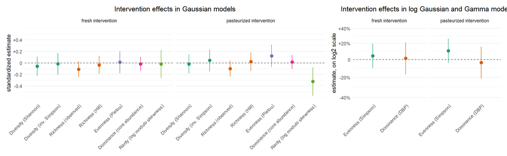

```r
# main model results
(gg_gaussian + gg_exp) + patchwork::plot_layout(nrow = 1, widths = c(.67,.33))
```

```r
# ggsave("alphaDiversity_modelResults.png", width = 13, height = 4)
```

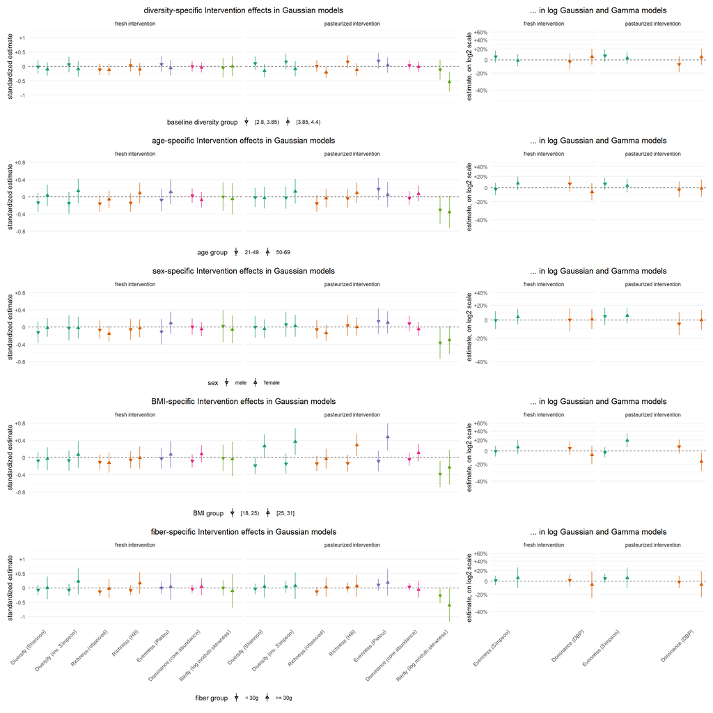

```r
# joint plot of all interactions
gg_div1 <- gg_gaussian_divInt + theme(axis.text.x = element_blank())
gg_div2 <- gg_exp_divInt + ggtitle("... in log Gaussian and Gamma models") +
  theme(axis.text.x = element_blank(), legend.position = "none")
gg_age1 <- gg_gaussian_ageInt + theme(axis.text.x = element_blank())
gg_age2 <- gg_exp_ageInt + ggtitle("... in log Gaussian and Gamma models") +
  theme(axis.text.x = element_blank(), legend.position = "none")
gg_sex1 <- gg_gaussian_sexInt + theme(axis.text.x = element_blank())
gg_sex2 <- gg_exp_sexInt + ggtitle("... in log Gaussian and Gamma models") +
  theme(axis.text.x = element_blank(), legend.position = "none")
gg_bmi1 <- gg_gaussian_bmiInt + theme(axis.text.x = element_blank())
gg_bmi2 <- gg_exp_bmiInt + ggtitle("... in log Gaussian and Gamma models") +
  theme(axis.text.x = element_blank(), legend.position = "none")
gg_fib1 <- gg_gaussian_fibInt
gg_fib2 <- gg_exp_fibInt + ggtitle("... in log Gaussian and Gamma models") +
  theme(legend.position = "none")

layout <- "
AAB
CCD
EEF
GGH
IIJ
"
gg_div1 + gg_div2 + gg_age1 + gg_age2 + gg_sex1 + gg_sex2 + gg_bmi1 + gg_bmi2 + gg_fib1 + gg_fib2 +
  patchwork::plot_layout(design = layout)
```

```r
# ggsave("FigureS3_alphaDiversity_stratifications.png", width = 16, height = 16)
```

## Joint figure of main effects and (p-value) significant BMI interactions

significance referring to the uncorrected p-values

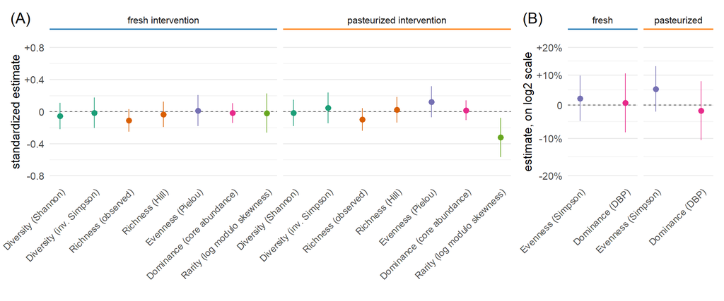

```r
### 1) prepare plot data for Gaussian effects
# retrieve main effect data
plot_dat_joint_gaussian <- results_dat %>%
  filter(model_type  == "Gaussian",
         param_group == "intervention") %>%
  mutate(parameter = factor(parameter, levels = c("interventionFresh", "interventionPasteurized"),
                            labels = c("fresh intervention", "pasteurized intervention")),
         model     = factor(model, levels = levels(model),
                            labels = levels(model) %>% gsub(pattern = " \\(Blood)", replacement = "")),
         param_type   = "main effect",
         model        = droplevels(model),
         model_xCoord = as.numeric(model),
         CI_alpha     = 1)
# retrieve significant BMI interaction effect data
plot_dat_joint_bmiInt_gaussian <- plot_dat_bmiInt %>%
  group_by(model, parameter) %>%
  filter(any(pvalue < 0.05)) %>%
  ungroup() %>%
  mutate(param_type   = paste0("Effect in BMI group ", bmi_group),
         xCoord_shift = case_when(bmi_group == min(bmi_group) ~ -0.3,
                                  TRUE                        ~ 0.3),
         model_xCoord = as.numeric(model) + xCoord_shift,
         CI_alpha     = 0.3)
# join the two datasets
plot_dat_joint_gaussian <- plot_dat_joint_gaussian %>%
  dplyr::bind_rows(plot_dat_joint_bmiInt_gaussian) %>%
  mutate(param_type = factor(param_type, levels = c("main effect", "Effect in BMI group [18, 25)",
                                                    "Effect in BMI group [25, 31]")))

# 2) create the Gaussian plot
gg_joint_gaussian <- plot_dat_joint_gaussian %>%
  filter(!is.na(param_group)) %>%
  ggplot(aes(x = model_xCoord, y = estimate_standardized, color = model_group, fill = model_group)) +
  geom_hline(yintercept = 0, linetype = 2, col = "gray30") +
  geom_linerange(aes(ymin = CI_lower_standardized, ymax = CI_upper_standardized, alpha = param_type)) +
  geom_point(aes(shape = param_type, size = param_type)) +
  scale_x_continuous(breaks = 1:length(levels(plot_dat_joint_gaussian$model)), labels = levels(plot_dat_joint_gaussian$model)) +
  scale_y_continuous("standardized estimate", limits = c(-.8, .8),
                     breaks = c(-.8,-.4,0,.4,.8),
                     labels = c("-0.8", "-0.4", "0", "+0.4", "+0.8")) +
  scale_color_brewer(palette = "Dark2", guide = "none") +
  scale_fill_brewer(palette = "Dark2", guide = "none") +
  scale_shape_manual(values = c(19, 25, 24)) +
  scale_alpha_manual(values = c(1, .3, .3), guide = "none") +
  scale_size_manual(values = c(3, 1.5, 1.5)) +
  facet_wrap(~ parameter) +
  theme_minimal(base_size = 14) +
  theme(plot.title       = element_blank(),
        panel.grid.minor = element_blank(),
        plot.background  = element_rect(fill = "white", color = "white"),
        axis.text.x        = element_text(hjust = 1, angle = 45),
        axis.text.y        = element_text(size = 12),
        axis.title.x       = element_blank(),
        panel.grid.minor.y = element_line(color = "gray96"),
        panel.grid.major.x = element_blank(),
        strip.text         = element_blank(),
        strip.background   = element_blank(),
        legend.position    = "none")

# 3) prepare plot data for multiplicative effects
# retrieve main effect data
plot_dat_joint_exp <- results_dat %>%
  filter(model_type  != "Gaussian",
         param_group == "intervention") %>%
  mutate(parameter = factor(parameter, levels = c("interventionFresh", "interventionPasteurized"),
                            labels = c("fresh intervention", "pasteurized intervention")),
         model     = factor(model, levels = levels(model),
                            labels = levels(model) %>% gsub(pattern = " \\(Blood)", replacement = "")),
         param_type   = "main effect",
         model        = droplevels(model),
         model_xCoord = as.numeric(model),
         CI_alpha     = 1)
# retrieve significant BMI interaction effect data
plot_dat_joint_bmiInt_exp <- plot_dat_bmiInt_exp %>%
  group_by(model, parameter) %>%
  filter(any(pvalue < 0.05)) %>%
  ungroup() %>%
  mutate(param_type   = paste0("Effect in BMI group ", bmi_group),
         xCoord_shift = case_when(bmi_group == min(bmi_group) ~ -0.2,
                                  TRUE                        ~ 0.2),
         model_xCoord = as.numeric(model) + xCoord_shift,
         CI_alpha     = 0.3)
# join the two datasets
plot_dat_joint_exp <- plot_dat_joint_exp %>%
  dplyr::bind_rows(plot_dat_joint_bmiInt_exp) %>%
  mutate(parameter    = gsub(parameter, pattern = " intervention", replacement = "")) %>%
  mutate(param_type = factor(param_type, levels = c("main effect", "Effect in BMI group [18, 25)",
                                                    "Effect in BMI group [25, 31]")))

# 4) create the multiplicative effects plot
gg_joint_exp <- plot_dat_joint_exp %>%
  filter(!is.na(param_group)) %>%
  ggplot(aes(x = model_xCoord, y = exp_estimate, color = model_group, fill = model_group)) +
  geom_hline(yintercept = 1, linetype = 2, col = "gray30") +
  geom_linerange(aes(ymin = exp_CIlower, ymax = exp_CIupper, alpha = param_type)) +
  geom_point(aes(shape = param_type, size = param_type)) +
  scale_x_continuous(breaks = 1:length(levels(plot_dat_bmiInt_exp$model)), labels = levels(plot_dat_bmiInt_exp$model),
                     limits = c(.8, 2.2)) +
  scale_y_continuous("estimate, on log2 scale", trans = "log2", limits = c(.8,1.2),
                     breaks = c(.8, .9, 1, 1.1, 1.2),
                     labels = c("-20%", "-10%", "0", "+10%", "+20%"),
                     minor_breaks = c(.85, .95, 1.05, 1.15)) +
  scale_color_manual(values = c("#7570B3","#E72A8A"), guide = "none") +
  scale_fill_manual(values = c("#7570B3","#E72A8A"), guide = "none") +
  scale_shape_manual(values = c(19, 25, 24)) +
  scale_alpha_manual(values = c(1, .3, .3), guide = "none") +
  scale_size_manual(values = c(3, 1.5, 1.5)) +
  facet_wrap(~ parameter) +
  theme_minimal(base_size = 14) +
  theme(plot.title       = element_blank(),
        panel.grid.minor = element_blank(),
        plot.background  = element_rect(fill = "white", color = "white"),
        axis.text.x        = element_text(hjust = 1, angle = 45),
        axis.text.y        = element_text(size = 12),
        axis.title.x       = element_blank(),
        panel.grid.minor.y = element_line(color = "gray96"),
        panel.grid.major.x = element_blank(),
        strip.text         = element_blank(),
        strip.background   = element_blank(),
        legend.position    = "none")


# 5) separate the plot title and the facet titles to plot it in a fancy version all above both plots
gg_titleGaussian <- data.frame("param" = rep(c("A","B"), times = 2),
                               "int"   = rep(c("fresh intervention","pasteurized intervention"), each = 2),
                               "value" = 1) %>%
  ggplot() +
  geom_hline(aes(col = int, yintercept = value), lwd = 2) +
  labs(tag = "(A)") +
  facet_wrap(~ int) +
  scale_color_manual(values = c("#1F78B4", "#FF7F00")) +
  theme_minimal(base_size = 14) +
  theme(plot.tag.location = "plot",
        plot.tag          = element_text(size = 18),
        panel.grid        = element_blank(),
        axis.text         = element_blank(),
        legend.position   = "none")
gg_titleExp <- data.frame("param" = rep(c("A","B"), times = 2),
                          "int"   = rep(c("fresh","pasteurized"), each = 2),
                          "value" = 1) %>%
  ggplot() +
  geom_hline(aes(col = int, yintercept = value), lwd = 2) +
  labs(tag = "(B)") +
  facet_wrap(~ int) +
  scale_color_manual(values = c("#1F78B4", "#FF7F00")) +
  theme_minimal(base_size = 14) +
  theme(plot.tag.location = "plot",
        plot.tag          = element_text(size = 18),
        panel.grid        = element_blank(),
        axis.text         = element_blank(),
        legend.position   = "none")

# 6) create the joint plot
layout <- "
AB
CD
EE
"
gg_titleGaussian + gg_titleExp + gg_joint_gaussian + gg_joint_exp + guide_area() +
  patchwork::plot_layout(nrow = 2, ncol = 2,
                         widths = c(.76, .24), heights = c(.01,2), guides = "collect", design = layout)
```

```r
# ggsave("Figure2_alphaDiversityModels.png", width = 12, height = 5)
```

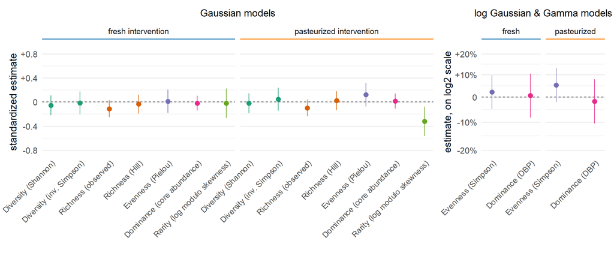

```r
# alternative joint plot, including titles

# 5) separate the plot title and the facet titles to plot it in a fancy version all above both plots
gg_titleGaussian <- data.frame("param" = rep(c("A","B"), times = 2),
                               "int"   = rep(c("fresh intervention","pasteurized intervention"), each = 2),
                               "value" = 1) %>%
  ggplot() +
  geom_hline(aes(col = int, yintercept = value), lwd = 2) +
  facet_wrap(~ int) +
  ggtitle("Gaussian models") +
  scale_color_manual(values = c("#1F78B4", "#FF7F00")) +
  theme_minimal(base_size = 14) +
  theme(plot.title  = element_text(hjust = 0.5, size = 14),
        panel.grid  = element_blank(),
        axis.text   = element_blank(),
        legend.position = "none")
gg_titleExp <- data.frame("param" = rep(c("A","B"), times = 2),
                          "int"   = rep(c("fresh","pasteurized"), each = 2),
                          "value" = 1) %>%
  ggplot() +
  geom_hline(aes(col = int, yintercept = value), lwd = 2) +
  facet_wrap(~ int) +
  ggtitle("log Gaussian & Gamma models") +
  scale_color_manual(values = c("#1F78B4", "#FF7F00")) +
  theme_minimal(base_size = 14) +
  theme(plot.title  = element_text(hjust = 0.5, size = 14),
        panel.grid  = element_blank(),
        axis.text   = element_blank(),
        legend.position = "none")

# 6) create the joint plot
layout <- "
AB
CD
EE
"
gg_titleGaussian + gg_titleExp + gg_joint_gaussian + gg_joint_exp + guide_area() +
  patchwork::plot_layout(nrow = 2, ncol = 2,
                         widths = c(.76, .24), heights = c(.01,2), guides = "collect", design = layout)
```

## Control variables

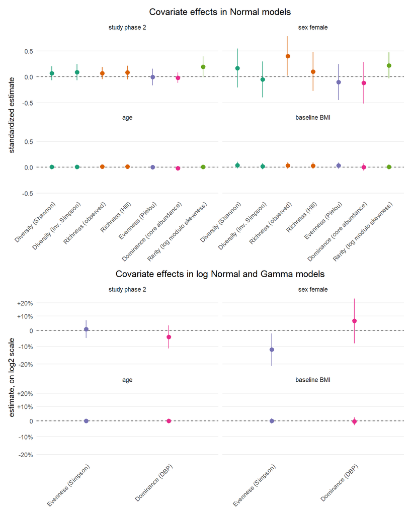

```r
### Blood

# 1) effects of Gaussian models
gg1 <- results_dat %>%
  filter(model_type  == "Gaussian",
         param_group %in% c("phase", "gender", "age", "BMI")) %>%
  mutate(parameter = factor(parameter,
                            levels = c("phasephase 2", "genderW", "age_centered50", "bmi_centered25"),
                            labels = c("study phase 2", "sex female", "age", "baseline BMI"))) %>%
  ggplot(aes(x = model, y = estimate_standardized, color = model_group)) +
  geom_hline(yintercept = 0, linetype = 2, col = "gray30") +
  geom_pointrange(aes(ymin = CI_lower_standardized, ymax = CI_upper_standardized)) +
  geom_point() +
  scale_y_continuous("standardized estimate") +
  scale_color_brewer(palette = "Dark2", guide = "none") +
  facet_wrap(~ parameter) +
  ggtitle("Covariate effects in Normal models") +
  theme(axis.text.x        = element_text(hjust = 1, angle = 45),
        axis.title.x       = element_blank(),
        panel.grid.major.x = element_blank(),
        legend.position    = "none")


# 2) effects of log Gaussian and Gamma models
gg2 <- results_dat %>%
  filter(model_type  != "Gaussian",
         param_group %in% c("phase", "gender", "age", "BMI")) %>%
  mutate(parameter = factor(parameter,
                            levels = c("phasephase 2", "genderW", "age_centered50", "bmi_centered25"),
                            labels = c("study phase 2", "sex female", "age", "baseline BMI"))) %>%
  ggplot(aes(x = model, y = exp_estimate, color = model_group)) +
  geom_hline(yintercept = 1, linetype = 2, col = "gray30") +
  geom_pointrange(aes(ymin = exp_CIlower, ymax = exp_CIupper)) +
  geom_point() +
  scale_y_continuous("estimate, on log2 scale", trans = "log2",
                     breaks = c(.8, .9, 1, 1.1, 1.2),
                     labels = c("-20%", "-10%", "0", "+10%", "+20%")) +
  scale_color_manual(values = c("#7570B3","#E72A8A")) +
  facet_wrap(~ parameter) +
  ggtitle("Covariate effects in log Normal and Gamma models") +
  theme(axis.text.x        = element_text(hjust = 1, angle = 45),
        axis.title.x       = element_blank(),
        panel.grid.major.x = element_blank(),
        legend.position    = "none")

# joint plot
gg1 / gg2
```

```r
# ggsave("FigureS8_alphaDiversityModels_controlVariables.png", width = 8, height = 10)
```